# Prediction of Salesrank for Amazon products

## Social Network Analysis

Team 2: Maryna Pavlenko, Daniel Lee, Yuzi Liu, Ziwei Liang

Analysis of product co-purchase data from Amazon. Poisson regression is used to predict salesrank of all the books using products’ own information and their neighbor’s information.

## [Data file](https://github.com/mpavlenk/Social-Network-Analysis)

Importing libraries

```r
library("igraph")
library("dplyr")
library("sqldf")
```

Loading datasets

```r
products <- read.csv("products.csv")
copurchase <- read.csv("copurchase.csv")
```

### Data processing

Deleting products that are not books from "products" and "copurchase" files

```r
products1 <- products[products$group == "Book", ]
Book <- subset(products1, salesrank <= 150000 & salesrank != -1)
Book$downloads <- NULL
copurchase1 <- subset(copurchase, Source %in% Book$id & Target %in% Book$id)
```

Creating a variable named 'in-degree', to show how many "Source" products people who buy "Target" products buy; i.e. how many edges to the focal product are in "co-purchase" network

```r
network <- graph.data.frame(copurchase1, directed = T)
indegree <- degree(network, mode = 'in')
```

Creating a variable named 'out-degree', to show how many "Target" products people who buy "Source" product also buy; i.e., how many edges from the focal product are in "co-purchase" network.

```r
outdegree <- degree(network, mode = 'out')
```

### Subcomponent

Picking up one of the products with highest degree (in-degree + out-degree) to find its subcomponent, i.e., to find all the products that are connected to this focal product.

```r
alldegree <- degree(network, mode = 'total')
max(alldegree)
```

53

```r
which(alldegree==53)
```

**4429**

308

**33**

17290

```r
sub_all <- subcomponent(network, "33",'all')
```

### Visualizations

```r
newgraph<-suppressWarnings(subgraph(network,sub_all))
diameter(newgraph, directed=F, weights=NA)
```

41

```r
diam <- get_diameter(newgraph, directed=T)
as.vector(diam)
```

1. 332

2. 265

3. 226

4. 138

5. 140

6. 162

7. 62

8. 30

9. 45

10. 837

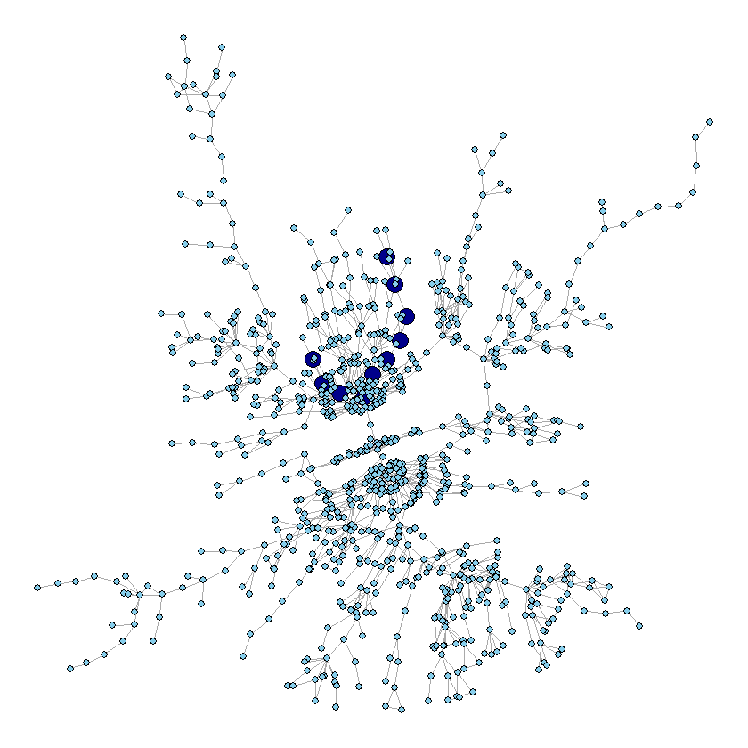

```r
# Visualizing the subcomponent using iGraph, highlighting the diameter, and coloring the nodes along the diameter.
# The graph demonstrates 904 vertices, 904 book ids which are connected with each other.  Some of them have stronger
# connections like clusters in the middle with short edges, some of them have weaker ties which are nodes on the edges
# of the plot. Diameter shows the longest geodesic distance between two vertices. We have defined node attributes for the
# diameter that is why it is plotted with larger nodes of dark blue color. In our visualization, the distance is 41
# and there are 10 vertices in the diameter (37895 27936 21584 10889 11080 14111 4429  2501  3588  6676) which have the
# longest distance between them.
V(newgraph)$color<-"skyblue"
V(newgraph)$size<-2
V(newgraph)[diam]$color<-"darkblue"
V(newgraph)[diam]$size<-5
par(mar=c(.1,.1,.1,.1))
plot.igraph(newgraph,
            vertex.label=NA,
            edge.arrow.size=0.00001,
            layout=layout.kamada.kawai)
```

### Network Statistics

Computing various statistics about this network (i.e., subcomponent), including degree distribution, density, and centrality (degree centrality, closeness centrality and between centrality), hub/authority scores, etc.

```r
deg1 <- degree(newgraph, mode = "all")
deg.dist.all <- degree_distribution(newgraph, cumulative=T, mode="all")
centr_degree(newgraph,mode="all",normalized=T)
```

**$res**

1. 4

2. 2

3. 2

4. 6

5. 11

6. 4

7. 5

8. 6

9. 4

10. 5

11. 3

12. 19

13. 2

14. 2

15. 5

16. 1

17. 2

18. 1

19. 1

20. 3

21. 4

22. 5

23. 3

24. 3

25. 5

26. 1

27. 3

28. 11

29. 2

30. 21

31. 5

32. 11

33. 2

34. 1

35. 2

36. 1

37. 4

38. 1

39. 2

40. 1

41. 1

42. 3

43. 2

44. 1

45. 3

46. 2

47. 1

48. 6

49. 3

50. 3

51. 6

52. 3

53. 2

54. 4

55. 2

56. 3

57. 2

58. 5

59. 2

60. 4

61. 2

62. 53

63. 2

64. 7

65. 3

66. 1

67. 3

68. 4

69. 5

70. 4

71. 1

72. 3

73. 3

74. 2

75. 3

76. 1

77. 4

78. 3

79. 1

80. 9

81. 7

82. 1

83. 4

84. 5

85. 2

86. 1

87. 1

88. 2

89. 2

90. 2

91. 9

92. 1

93. 2

94. 2

95. 3

96. 3

97. 3

98. 4

99. 6

100. 2

101. 2

102. 9

103. 5

104. 6

105. 5

106. 2

107. 1

108. 2

109. 3

110. 3

111. 2

112. 9

113. 3

114. 3

115. 1

116. 2

117. 3

118. 3

119. 2

120. 5

121. 7

122. 2

123. 5

124. 3

125. 4

126. 2

127. 5

128. 3

129. 3

130. 3

131. 2

132. 1

133. 3

134. 1

135. 1

136. 6

137. 1

138. 5

139. 3

140. 3

141. 2

142. 4

143. 1

144. 1

145. 10

146. 1

147. 3

148. 1

149. 5

150. 2

151. 1

152. 2

153. 2

154. 2

155. 1

156. 2

157. 2

158. 4

159. 4

160. 3

161. 3

162. 5

163. 2

164. 2

165. 1

166. 3

167. 2

168. 1

169. 4

170. 1

171. 5

172. 3

173. 3

174. 3

175. 1

176. 1

177. 2

178. 2

179. 1

180. 4

181. 1

182. 1

183. 2

184. 5

185. 3

186. 2

187. 3

188. 1

189. 3

190. 4

191. 2

192. 3

193. 1

194. 4

195. 7

196. 1

197. 1

198. 2

199. 1

200. 1

201. 2

202. 1

203. 2

204. 4

205. 3

206. 2

207. 5

208. 2

209. 4

210. 7

211. 1

212. 2

213. 1

214. 2

215. 2

216. 6

217. 3

218. 1

219. 3

220. 1

221. 3

222. 1

223. 4

224. 4

225. 3

226. 3

227. 3

228. 3

229. 2

230. 1

231. 1

232. 3

233. 1

234. 6

235. 3

236. 2

237. 1

238. 1

239. 2

240. 4

241. 3

242. 1

243. 2

244. 4

245. 2

246. 6

247. 1

248. 6

249. 7

250. 3

251. 3

252. 1

253. 1

254. 2

255. 1

256. 3

257. 2

258. 3

259. 1

260. 4

261. 2

262. 1

263. 1

264. 1

265. 3

266. 5

267. 2

268. 2

269. 3

270. 1

271. 2

272. 1

273. 3

274. 2

275. 1

276. 4

277. 2

278. 2

279. 5

280. 1

281. 4

282. 4

283. 1

284. 1

285. 1

286. 2

287. 3

288. 1

289. 7

290. 2

291. 1

292. 1

293. 3

294. 3

295. 2

296. 3

297. 1

298. 4

299. 4

300. 1

301. 1

302. 1

303. 1

304. 6

305. 1

306. 2

307. 3

308. 2

309. 1

310. 2

311. 5

312. 2

313. 1

314. 1

315. 2

316. 1

317. 1

318. 3

319. 5

320. 2

321. 4

322. 3

323. 1

324. 2

325. 3

326. 2

327. 1

328. 3

329. 1

330. 2

331. 3

332. 2

333. 1

334. 1

335. 2

336. 1

337. 2

338. 1

339. 2

340. 2

341. 3

342. 3

343. 3

344. 7

345. 2

346. 2

347. 5

348. 1

349. 1

350. 1

351. 6

352. 2

353. 3

354. 2

355. 1

356. 4

357. 2

358. 4

359. 5

360. 4

361. 2

362. 2

363. 1

364. 4

365. 4

366. 1

367. 1

368. 1

369. 5

370. 2

371. 2

372. 3

373. 3

374. 6

375. 1

376. 2

377. 7

378. 1

379. 3

380. 1

381. 1

382. 3

383. 4

384. 1

385. 3

386. 3

387. 3

388. 2

389. 1

390. 2

391. 3

392. 2

393. 3

394. 3

395. 1

396. 1

397. 1

398. 1

399. 3

400. 1

401. 1

402. 10

403. 3

404. 3

405. 3

406. 1

407. 6

408. 2

409. 1

410. 1

411. 1

412. 1

413. 2

414. 3

415. 3

416. 1

417. 1

418. 3

419. 3

420. 2

421. 1

422. 5

423. 1

424. 1

425. 2

426. 3

427. 1

428. 5

429. 1

430. 2

431. 2

432. 3

433. 1

434. 3

435. 2

436. 3

437. 1

438. 1

439. 3

440. 3

441. 3

442. 2

443. 1

444. 3

445. 2

446. 2

447. 1

448. 1

449. 1

450. 1

451. 1

452. 2

453. 2

454. 1

455. 5

456. 1

457. 3

458. 2

459. 2

460. 2

461. 5

462. 2

463. 1

464. 4

465. 2

466. 2

467. 3

468. 2

469. 1

470. 1

471. 1

472. 4

473. 1

474. 2

475. 1

476. 1

477. 1

478. 2

479. 4

480. 1

481. 3

482. 1

483. 4

484. 3

485. 3

486. 5

487. 2

488. 3

489. 1

490. 2

491. 6

492. 2

493. 3

494. 1

495. 2

496. 2

497. 3

498. 1

499. 5

500. 7

501. 1

502. 2

503. 1

504. 1

505. 4

506. 4

507. 1

508. 2

509. 2

510. 2

511. 3

512. 1

513. 2

514. 1

515. 1

516. 2

517. 3

518. 1

519. 1

520. 1

521. 4

522. 4

523. 3

524. 1

525. 2

526. 1

527. 1

528. 3

529. 2

530. 1

531. 2

532. 1

533. 1

534. 2

535. 2

536. 2

537. 1

538. 1

539. 1

540. 1

541. 2

542. 2

543. 3

544. 1

545. 1

546. 2

547. 2

548. 1

549. 1

550. 1

551. 3

552. 3

553. 1

554. 1

555. 1

556. 1

557. 1

558. 2

559. 1

560. 1

561. 1

562. 2

563. 2

564. 2

565. 1

566. 1

567. 2

568. 4

569. 3

570. 7

571. 4

572. 1

573. 2

574. 3

575. 1

576. 1

577. 2

578. 5

579. 1

580. 4

581. 1

582. 1

583. 1

584. 1

585. 1

586. 5

587. 4

588. 1

589. 1

590. 2

591. 1

592. 1

593. 1

594. 1

595. 3

596. 3

597. 3

598. 1

599. 2

600. 2

601. 4

602. 1

603. 1

604. 2

605. 1

606. 1

607. 3

608. 4

609. 1

610. 3

611. 3

612. 2

613. 3

614. 4

615. 2

616. 1

617. 4

618. 1

619. 1

620. 3

621. 1

622. 2

623. 1

624. 1

625. 3

626. 5

627. 1

628. 3

629. 1

630. 2

631. 2

632. 2

633. 2

634. 1

635. 3

636. 2

637. 3

638. 3

639. 3

640. 3

641. 2

642. 1

643. 1

644. 2

645. 3

646. 3

647. 1

648. 2

649. 2

650. 1

651. 4

652. 1

653. 1

654. 1

655. 2

656. 2

657. 4

658. 2

659. 5

660. 1

661. 1

662. 2

663. 1

664. 2

665. 1

666. 2

667. 2

668. 3

669. 3

670. 2

671. 3

672. 1

673. 6

674. 3

675. 1

676. 4

677. 3

678. 1

679. 1

680. 1

681. 1

682. 1

683. 2

684. 3

685. 2

686. 1

687. 1

688. 1

689. 1

690. 1

691. 2

692. 2

693. 3

694. 1

695. 3

696. 2

697. 3

698. 1

699. 1

700. 1

701. 1

702. 3

703. 1

704. 3

705. 1

706. 3

707. 3

708. 1

709. 1

710. 1

711. 1

712. 1

713. 3

714. 2

715. 4

716. 3

717. 3

718. 1

719. 1

720. 1

721. 2

722. 1

723. 1

724. 1

725. 3

726. 3

727. 2

728. 1

729. 2

730. 1

731. 1

732. 1

733. 1

734. 2

735. 1

736. 1

737. 3

738. 1

739. 3

740. 3

741. 2

742. 1

743. 1

744. 1

745. 2

746. 2

747. 2

748. 2

749. 1

750. 1

751. 3

752. 2

753. 1

754. 1

755. 3

756. 1

757. 3

758. 2

759. 2

760. 2

761. 1

762. 2

763. 2

764. 3

765. 1

766. 2

767. 2

768. 1

769. 1

770. 3

771. 2

772. 1

773. 1

774. 1

775. 1

776. 2

777. 2

778. 3

779. 2

780. 1

781. 1

782. 1

783. 1

784. 1

785. 2

786. 3

787. 1

788. 2

789. 1

790. 2

791. 3

792. 1

793. 1

794. 1

795. 1

796. 1

797. 1

798. 2

799. 1

800. 1

801. 1

802. 1

803. 2

804. 1

805. 1

806. 5

807. 1

808. 1

809. 4

810. 2

811. 2

812. 4

813. 3

814. 4

815. 3

816. 2

817. 1

818. 3

819. 1

820. 3

821. 3

822. 2

823. 2

824. 4

825. 3

826. 2

827. 11

828. 22

829. 53

830. 10

831. 12

832. 2

833. 2

834. 5

835. 1

836. 2

837. 2

838. 15

839. 2

840. 10

841. 3

842. 8

843. 3

844. 14

845. 3

846. 1

847. 2

848. 4

849. 1

850. 8

851. 2

852. 3

853. 1

854. 1

855. 13

856. 1

857. 5

858. 4

859. 1

860. 8

861. 2

862. 3

863. 2

864. 1

865. 1

866. 1

867. 1

868. 1

869. 2

870. 1

871. 1

872. 1

873. 4

874. 1

875. 1

876. 1

877. 1

878. 2

879. 2

880. 1

881. 4

882. 1

883. 4

884. 2

885. 2

886. 1

887. 1

888. 1

889. 1

890. 4

891. 2

892. 3

893. 1

894. 1

895. 1

896. 1

897. 1

898. 1

899. 2

900. 1

901. 1

902. 1

903. 1

904. 1

**$centralization**

0.027940579512858

**$theoretical_max**

1630818

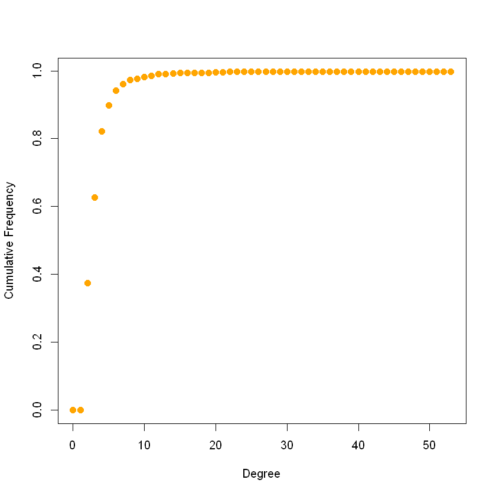

```r
plot( x=0:max(deg1), y=1-deg.dist.all, pch=19, cex=1.2, col="orange",
      xlab="Degree", ylab="Cumulative Frequency")
```

```r
deg2 <- degree(newgraph, mode = "in")
deg.dist.in <- degree_distribution(newgraph, cumulative=T, mode="in")
centr_degree(newgraph,mode="in",normalized=T)
```

**$res**

1. 3

2. 1

3. 1

4. 3

5. 10

6. 2

7. 2

8. 3

9. 2

10. 4

11. 2

12. 18

13. 1

14. 1

15. 3

16. 0

17. 0

18. 0

19. 0

20. 2

21. 2

22. 3

23. 2

24. 1

25. 3

26. 0

27. 1

28. 10

29. 1

30. 20

31. 4

32. 10

33. 0

34. 0

35. 1

36. 0

37. 3

38. 0

39. 1

40. 0

41. 0

42. 2

43. 0

44. 0

45. 1

46. 0

47. 0

48. 5

49. 2

50. 2

51. 5

52. 1

53. 1

54. 2

55. 1

56. 1

57. 1

58. 2

59. 1

60. 2

61. 1

62. 52

63. 1

64. 3

65. 2

66. 0

67. 2

68. 3

69. 4

70. 2

71. 0

72. 2

73. 1

74. 1

75. 1

76. 0

77. 3

78. 2

79. 0

80. 8

81. 6

82. 0

83. 2

84. 3

85. 0

86. 0

87. 0

88. 0

89. 1

90. 1

91. 8

92. 0

93. 1

94. 0

95. 1

96. 2

97. 1

98. 1

99. 4

100. 1

101. 1

102. 7

103. 3

104. 5

105. 3

106. 1

107. 0

108. 1

109. 1

110. 1

111. 1

112. 7

113. 1

114. 1

115. 0

116. 1

117. 2

118. 1

119. 0

120. 3

121. 6

122. 0

123. 2

124. 2

125. 3

126. 1

127. 4

128. 2

129. 2

130. 1

131. 0

132. 0

133. 1

134. 0

135. 0

136. 5

137. 0

138. 4

139. 2

140. 1

141. 1

142. 2

143. 0

144. 0

145. 8

146. 0

147. 2

148. 0

149. 3

150. 0

151. 0

152. 1

153. 1

154. 1

155. 0

156. 1

157. 0

158. 2

159. 2

160. 1

161. 2

162. 3

163. 1

164. 1

165. 0

166. 2

167. 0

168. 0

169. 3

170. 0

171. 4

172. 1

173. 1

174. 2

175. 0

176. 0

177. 0

178. 1

179. 0

180. 1

181. 0

182. 0

183. 1

184. 2

185. 2

186. 0

187. 1

188. 0

189. 1

190. 3

191. 0

192. 1

193. 0

194. 2

195. 4

196. 0

197. 0

198. 1

199. 0

200. 0

201. 1

202. 0

203. 1

204. 3

205. 2

206. 1

207. 2

208. 0

209. 2

210. 5

211. 0

212. 0

213. 0

214. 1

215. 1

216. 4

217. 1

218. 0

219. 2

220. 0

221. 2

222. 0

223. 1

224. 2

225. 2

226. 1

227. 1

228. 2

229. 1

230. 0

231. 0

232. 2

233. 0

234. 5

235. 1

236. 1

237. 0

238. 0

239. 1

240. 1

241. 2

242. 0

243. 1

244. 1

245. 1

246. 4

247. 0

248. 3

249. 3

250. 2

251. 1

252. 0

253. 0

254. 1

255. 0

256. 1

257. 1

258. 2

259. 0

260. 2

261. 1

262. 0

263. 0

264. 0

265. 2

266. 1

267. 1

268. 1

269. 2

270. 0

271. 1

272. 0

273. 2

274. 0

275. 0

276. 2

277. 0

278. 1

279. 2

280. 0

281. 1

282. 1

283. 0

284. 0

285. 0

286. 1

287. 1

288. 0

289. 5

290. 1

291. 0

292. 0

293. 1

294. 2

295. 1

296. 1

297. 0

298. 2

299. 2

300. 0

301. 0

302. 0

303. 0

304. 3

305. 0

306. 0

307. 2

308. 1

309. 0

310. 1

311. 3

312. 0

313. 0

314. 0

315. 0

316. 0

317. 0

318. 1

319. 3

320. 1

321. 2

322. 1

323. 0

324. 1

325. 2

326. 0

327. 0

328. 2

329. 0

330. 1

331. 1

332. 0

333. 0

334. 0

335. 1

336. 0

337. 1

338. 0

339. 1

340. 1

341. 1

342. 1

343. 1

344. 3

345. 1

346. 0

347. 4

348. 0

349. 0

350. 0

351. 2

352. 1

353. 1

354. 1

355. 0

356. 2

357. 1

358. 2

359. 3

360. 2

361. 1

362. 1

363. 0

364. 2

365. 2

366. 0

367. 0

368. 0

369. 3

370. 1

371. 1

372. 1

373. 2

374. 2

375. 0

376. 0

377. 4

378. 0

379. 2

380. 0

381. 0

382. 1

383. 1

384. 0

385. 1

386. 1

387. 2

388. 0

389. 0

390. 0

391. 2

392. 0

393. 1

394. 1

395. 0

396. 0

397. 0

398. 0

399. 1

400. 0

401. 0

402. 7

403. 1

404. 1

405. 1

406. 0

407. 4

408. 0

409. 0

410. 0

411. 0

412. 0

413. 1

414. 2

415. 1

416. 0

417. 0

418. 2

419. 1

420. 0

421. 0

422. 3

423. 0

424. 0

425. 0

426. 2

427. 0

428. 3

429. 0

430. 1

431. 1

432. 1

433. 0

434. 2

435. 1

436. 1

437. 0

438. 0

439. 1

440. 1

441. 1

442. 0

443. 0

444. 1

445. 0

446. 0

447. 0

448. 0

449. 0

450. 0

451. 0

452. 1

453. 1

454. 0

455. 3

456. 0

457. 1

458. 1

459. 0

460. 1

461. 4

462. 0

463. 0

464. 1

465. 0

466. 1

467. 1

468. 1

469. 0

470. 0

471. 0

472. 3

473. 0

474. 1

475. 0

476. 0

477. 0

478. 1

479. 2

480. 0

481. 1

482. 0

483. 2

484. 1

485. 1

486. 2

487. 0

488. 0

489. 0

490. 0

491. 4

492. 0

493. 2

494. 0

495. 1

496. 0

497. 1

498. 0

499. 3

500. 5

501. 0

502. 0

503. 0

504. 0

505. 2

506. 2

507. 0

508. 0

509. 1

510. 0

511. 2

512. 0

513. 0

514. 0

515. 0

516. 1

517. 1

518. 0

519. 0

520. 0

521. 2

522. 2

523. 1

524. 0

525. 0

526. 0

527. 0

528. 1

529. 1

530. 0

531. 1

532. 0

533. 0

534. 1

535. 0

536. 1

537. 0

538. 0

539. 0

540. 0

541. 1

542. 1

543. 0

544. 0

545. 0

546. 0

547. 1

548. 0

549. 0

550. 0

551. 1

552. 1

553. 0

554. 0

555. 0

556. 0

557. 0

558. 0

559. 0

560. 0

561. 0

562. 0

563. 1

564. 1

565. 0

566. 0

567. 0

568. 1

569. 2

570. 5

571. 1

572. 0

573. 1

574. 1

575. 0

576. 0

577. 0

578. 3

579. 0

580. 2

581. 0

582. 0

583. 0

584. 0

585. 0

586. 2

587. 2

588. 0

589. 0

590. 1

591. 0

592. 0

593. 0

594. 0

595. 1

596. 1

597. 1

598. 0

599. 1

600. 1

601. 2

602. 0

603. 0

604. 0

605. 0

606. 0

607. 1

608. 2

609. 0

610. 1

611. 2

612. 1

613. 1

614. 1

615. 1

616. 0

617. 2

618. 0

619. 0

620. 1

621. 0

622. 1

623. 0

624. 0

625. 2

626. 2

627. 0

628. 1

629. 0

630. 1

631. 1

632. 0

633. 1

634. 0

635. 1

636. 0

637. 2

638. 1

639. 2

640. 2

641. 1

642. 0

643. 0

644. 0

645. 1

646. 2

647. 0

648. 1

649. 1

650. 0

651. 2

652. 0

653. 0

654. 0

655. 1

656. 1

657. 2

658. 0

659. 2

660. 0

661. 0

662. 1

663. 0

664. 1

665. 0

666. 1

667. 1

668. 1

669. 2

670. 1

671. 1

672. 0

673. 5

674. 1

675. 0

676. 3

677. 1

678. 0

679. 0

680. 0

681. 0

682. 0

683. 0

684. 1

685. 0

686. 0

687. 0

688. 0

689. 0

690. 0

691. 0

692. 1

693. 1

694. 0

695. 1

696. 0

697. 1

698. 0

699. 0

700. 0

701. 0

702. 1

703. 0

704. 1

705. 0

706. 1

707. 1

708. 0

709. 0

710. 0

711. 0

712. 0

713. 1

714. 0

715. 1

716. 1

717. 1

718. 0

719. 0

720. 0

721. 1

722. 0

723. 0

724. 0

725. 0

726. 1

727. 1

728. 0

729. 1

730. 0

731. 0

732. 0

733. 0

734. 1

735. 0

736. 0

737. 1

738. 0

739. 1

740. 1

741. 0

742. 0

743. 0

744. 0

745. 0

746. 1

747. 1

748. 1

749. 0

750. 0

751. 1

752. 1

753. 0

754. 0

755. 1

756. 0

757. 1

758. 1

759. 1

760. 0

761. 0

762. 1

763. 1

764. 1

765. 0

766. 0

767. 0

768. 0

769. 0

770. 2

771. 0

772. 0

773. 0

774. 0

775. 0

776. 0

777. 0

778. 2

779. 0

780. 0

781. 0

782. 0

783. 0

784. 0

785. 0

786. 0

787. 0

788. 0

789. 0

790. 1

791. 1

792. 0

793. 0

794. 0

795. 0

796. 0

797. 0

798. 0

799. 0

800. 0

801. 0

802. 0

803. 0

804. 0

805. 0

806. 3

807. 0

808. 0

809. 2

810. 0

811. 0

812. 2

813. 1

814. 2

815. 1

816. 1

817. 0

818. 1

819. 0

820. 1

821. 1

822. 0

823. 1

824. 2

825. 1

826. 1

827. 11

828. 22

829. 53

830. 10

831. 12

832. 2

833. 2

834. 5

835. 1

836. 2

837. 2

838. 15

839. 2

840. 10

841. 3

842. 8

843. 3

844. 14

845. 3

846. 1

847. 2

848. 4

849. 1

850. 8

851. 2

852. 3

853. 1

854. 1

855. 13

856. 1

857. 5

858. 4

859. 1

860. 8

861. 2

862. 3

863. 2

864. 1

865. 1

866. 1

867. 1

868. 1

869. 2

870. 1

871. 1

872. 1

873. 4

874. 1

875. 1

876. 1

877. 1

878. 2

879. 2

880. 1

881. 4

882. 1

883. 4

884. 2

885. 2

886. 1

887. 1

888. 1

889. 1

890. 4

891. 2

892. 3

893. 1

894. 1

895. 1

896. 1

897. 1

898. 1

899. 2

900. 1

901. 1

902. 1

903. 1

904. 1

**$centralization**

0.0572562941620361

**$theoretical_max**

816312

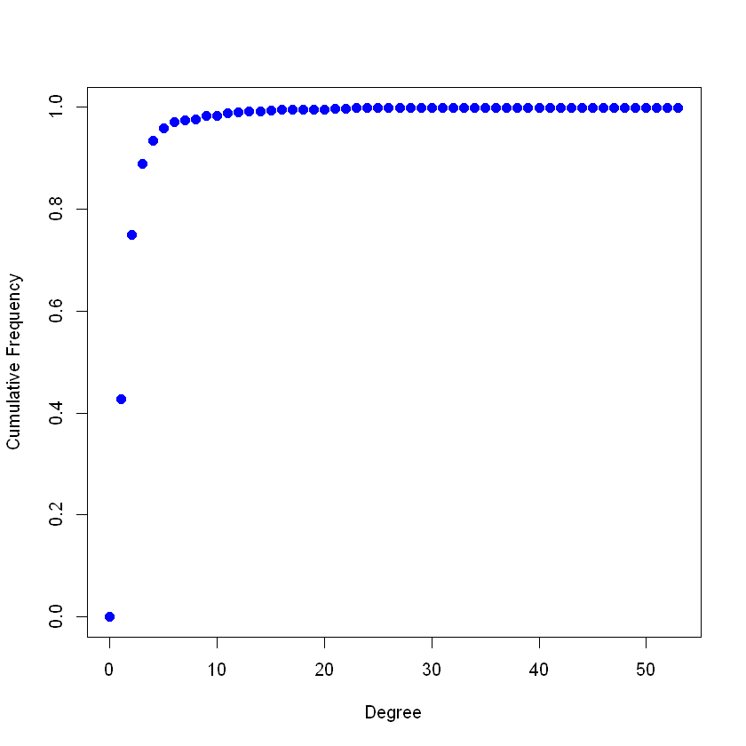

```r
plot( x=0:max(deg2), y=1-deg.dist.in, pch=19, cex=1.2, col="blue",
      xlab="Degree", ylab="Cumulative Frequency")
```

```r
deg3 <- degree(newgraph, mode = "out")
deg.dist.out <- degree_distribution(newgraph, cumulative=T, mode="out")
centr_degree(newgraph,mode="out",normalized=T)
```

**$res**

1. 1

2. 1

3. 1

4. 3

5. 1

6. 2

7. 3

8. 3

9. 2

10. 1

11. 1

12. 1

13. 1

14. 1

15. 2

16. 1

17. 2

18. 1

19. 1

20. 1

21. 2

22. 2

23. 1

24. 2

25. 2

26. 1

27. 2

28. 1

29. 1

30. 1

31. 1

32. 1

33. 2

34. 1

35. 1

36. 1

37. 1

38. 1

39. 1

40. 1

41. 1

42. 1

43. 2

44. 1

45. 2

46. 2

47. 1

48. 1

49. 1

50. 1

51. 1

52. 2

53. 1

54. 2

55. 1

56. 2

57. 1

58. 3

59. 1

60. 2

61. 1

62. 1

63. 1

64. 4

65. 1

66. 1

67. 1

68. 1

69. 1

70. 2

71. 1

72. 1

73. 2

74. 1

75. 2

76. 1

77. 1

78. 1

79. 1

80. 1

81. 1

82. 1

83. 2

84. 2

85. 2

86. 1

87. 1

88. 2

89. 1

90. 1

91. 1

92. 1

93. 1

94. 2

95. 2

96. 1

97. 2

98. 3

99. 2

100. 1

101. 1

102. 2

103. 2

104. 1

105. 2

106. 1

107. 1

108. 1

109. 2

110. 2

111. 1

112. 2

113. 2

114. 2

115. 1

116. 1

117. 1

118. 2

119. 2

120. 2

121. 1

122. 2

123. 3

124. 1

125. 1

126. 1

127. 1

128. 1

129. 1

130. 2

131. 2

132. 1

133. 2

134. 1

135. 1

136. 1

137. 1

138. 1

139. 1

140. 2

141. 1

142. 2

143. 1

144. 1

145. 2

146. 1

147. 1

148. 1

149. 2

150. 2

151. 1

152. 1

153. 1

154. 1

155. 1

156. 1

157. 2

158. 2

159. 2

160. 2

161. 1

162. 2

163. 1

164. 1

165. 1

166. 1

167. 2

168. 1

169. 1

170. 1

171. 1

172. 2

173. 2

174. 1

175. 1

176. 1

177. 2

178. 1

179. 1

180. 3

181. 1

182. 1

183. 1

184. 3

185. 1

186. 2

187. 2

188. 1

189. 2

190. 1

191. 2

192. 2

193. 1

194. 2

195. 3

196. 1

197. 1

198. 1

199. 1

200. 1

201. 1

202. 1

203. 1

204. 1

205. 1

206. 1

207. 3

208. 2

209. 2

210. 2

211. 1

212. 2

213. 1

214. 1

215. 1

216. 2

217. 2

218. 1

219. 1

220. 1

221. 1

222. 1

223. 3

224. 2

225. 1

226. 2

227. 2

228. 1

229. 1

230. 1

231. 1

232. 1

233. 1

234. 1

235. 2

236. 1

237. 1

238. 1

239. 1

240. 3

241. 1

242. 1

243. 1

244. 3

245. 1

246. 2

247. 1

248. 3

249. 4

250. 1

251. 2

252. 1

253. 1

254. 1

255. 1

256. 2

257. 1

258. 1

259. 1

260. 2

261. 1

262. 1

263. 1

264. 1

265. 1

266. 4

267. 1

268. 1

269. 1

270. 1

271. 1

272. 1

273. 1

274. 2

275. 1

276. 2

277. 2

278. 1

279. 3

280. 1

281. 3

282. 3

283. 1

284. 1

285. 1

286. 1

287. 2

288. 1

289. 2

290. 1

291. 1

292. 1

293. 2

294. 1

295. 1

296. 2

297. 1

298. 2

299. 2

300. 1

301. 1

302. 1

303. 1

304. 3

305. 1

306. 2

307. 1

308. 1

309. 1

310. 1

311. 2

312. 2

313. 1

314. 1

315. 2

316. 1

317. 1

318. 2

319. 2

320. 1

321. 2

322. 2

323. 1

324. 1

325. 1

326. 2

327. 1

328. 1

329. 1

330. 1

331. 2

332. 2

333. 1

334. 1

335. 1

336. 1

337. 1

338. 1

339. 1

340. 1

341. 2

342. 2

343. 2

344. 4

345. 1

346. 2

347. 1

348. 1

349. 1

350. 1

351. 4

352. 1

353. 2

354. 1

355. 1

356. 2

357. 1

358. 2

359. 2

360. 2

361. 1

362. 1

363. 1

364. 2

365. 2

366. 1

367. 1

368. 1

369. 2

370. 1

371. 1

372. 2

373. 1

374. 4

375. 1

376. 2

377. 3

378. 1

379. 1

380. 1

381. 1

382. 2

383. 3

384. 1

385. 2

386. 2

387. 1

388. 2

389. 1

390. 2

391. 1

392. 2

393. 2

394. 2

395. 1

396. 1

397. 1

398. 1

399. 2

400. 1

401. 1

402. 3

403. 2

404. 2

405. 2

406. 1

407. 2

408. 2

409. 1

410. 1

411. 1

412. 1

413. 1

414. 1

415. 2

416. 1

417. 1

418. 1

419. 2

420. 2

421. 1

422. 2

423. 1

424. 1

425. 2

426. 1

427. 1

428. 2

429. 1

430. 1

431. 1

432. 2

433. 1

434. 1

435. 1

436. 2

437. 1

438. 1

439. 2

440. 2

441. 2

442. 2

443. 1

444. 2

445. 2

446. 2

447. 1

448. 1

449. 1

450. 1

451. 1

452. 1

453. 1

454. 1

455. 2

456. 1

457. 2

458. 1

459. 2

460. 1

461. 1

462. 2

463. 1

464. 3

465. 2

466. 1

467. 2

468. 1

469. 1

470. 1

471. 1

472. 1

473. 1

474. 1

475. 1

476. 1

477. 1

478. 1

479. 2

480. 1

481. 2

482. 1

483. 2

484. 2

485. 2

486. 3

487. 2

488. 3

489. 1

490. 2

491. 2

492. 2

493. 1

494. 1

495. 1

496. 2

497. 2

498. 1

499. 2

500. 2

501. 1

502. 2

503. 1

504. 1

505. 2

506. 2

507. 1

508. 2

509. 1

510. 2

511. 1

512. 1

513. 2

514. 1

515. 1

516. 1

517. 2

518. 1

519. 1

520. 1

521. 2

522. 2

523. 2

524. 1

525. 2

526. 1

527. 1

528. 2

529. 1

530. 1

531. 1

532. 1

533. 1

534. 1

535. 2

536. 1

537. 1

538. 1

539. 1

540. 1

541. 1

542. 1

543. 3

544. 1

545. 1

546. 2

547. 1

548. 1

549. 1

550. 1

551. 2

552. 2

553. 1

554. 1

555. 1

556. 1

557. 1

558. 2

559. 1

560. 1

561. 1

562. 2

563. 1

564. 1

565. 1

566. 1

567. 2

568. 3

569. 1

570. 2

571. 3

572. 1

573. 1

574. 2

575. 1

576. 1

577. 2

578. 2

579. 1

580. 2

581. 1

582. 1

583. 1

584. 1

585. 1

586. 3

587. 2

588. 1

589. 1

590. 1

591. 1

592. 1

593. 1

594. 1

595. 2

596. 2

597. 2

598. 1

599. 1

600. 1

601. 2

602. 1

603. 1

604. 2

605. 1

606. 1

607. 2

608. 2

609. 1

610. 2

611. 1

612. 1

613. 2

614. 3

615. 1

616. 1

617. 2

618. 1

619. 1

620. 2

621. 1

622. 1

623. 1

624. 1

625. 1

626. 3

627. 1

628. 2

629. 1

630. 1

631. 1

632. 2

633. 1

634. 1

635. 2

636. 2

637. 1

638. 2

639. 1

640. 1

641. 1

642. 1

643. 1

644. 2

645. 2

646. 1

647. 1

648. 1

649. 1

650. 1

651. 2

652. 1

653. 1

654. 1

655. 1

656. 1

657. 2

658. 2

659. 3

660. 1

661. 1

662. 1

663. 1

664. 1

665. 1

666. 1

667. 1

668. 2

669. 1

670. 1

671. 2

672. 1

673. 1

674. 2

675. 1

676. 1

677. 2

678. 1

679. 1

680. 1

681. 1

682. 1

683. 2

684. 2

685. 2

686. 1

687. 1

688. 1

689. 1

690. 1

691. 2

692. 1

693. 2

694. 1

695. 2

696. 2

697. 2

698. 1

699. 1

700. 1

701. 1

702. 2

703. 1

704. 2

705. 1

706. 2

707. 2

708. 1

709. 1

710. 1

711. 1

712. 1

713. 2

714. 2

715. 3

716. 2

717. 2

718. 1

719. 1

720. 1

721. 1

722. 1

723. 1

724. 1

725. 3

726. 2

727. 1

728. 1

729. 1

730. 1

731. 1

732. 1

733. 1

734. 1

735. 1

736. 1

737. 2

738. 1

739. 2

740. 2

741. 2

742. 1

743. 1

744. 1

745. 2

746. 1

747. 1

748. 1

749. 1

750. 1

751. 2

752. 1

753. 1

754. 1

755. 2

756. 1

757. 2

758. 1

759. 1

760. 2

761. 1

762. 1

763. 1

764. 2

765. 1

766. 2

767. 2

768. 1

769. 1

770. 1

771. 2

772. 1

773. 1

774. 1

775. 1

776. 2

777. 2

778. 1

779. 2

780. 1

781. 1

782. 1

783. 1

784. 1

785. 2

786. 3

787. 1

788. 2

789. 1

790. 1

791. 2

792. 1

793. 1

794. 1

795. 1

796. 1

797. 1

798. 2

799. 1

800. 1

801. 1

802. 1

803. 2

804. 1

805. 1

806. 2

807. 1

808. 1

809. 2

810. 2

811. 2

812. 2

813. 2

814. 2

815. 2

816. 1

817. 1

818. 2

819. 1

820. 2

821. 2

822. 2

823. 1

824. 2

825. 2

826. 1

827. 0

828. 0

829. 0

830. 0

831. 0

832. 0

833. 0

834. 0

835. 0

836. 0

837. 0

838. 0

839. 0

840. 0

841. 0

842. 0

843. 0

844. 0

845. 0

846. 0

847. 0

848. 0

849. 0

850. 0

851. 0

852. 0

853. 0

854. 0

855. 0

856. 0

857. 0

858. 0

859. 0

860. 0

861. 0

862. 0

863. 0

864. 0

865. 0

866. 0

867. 0

868. 0

869. 0

870. 0

871. 0

872. 0

873. 0

874. 0

875. 0

876. 0

877. 0

878. 0

879. 0

880. 0

881. 0

882. 0

883. 0

884. 0

885. 0

886. 0

887. 0

888. 0

889. 0

890. 0

891. 0

892. 0

893. 0

894. 0

895. 0

896. 0

897. 0

898. 0

899. 0

900. 0

901. 0

902. 0

903. 0

904. 0

**$centralization**

0.00299272827056322

**$theoretical_max**

816312

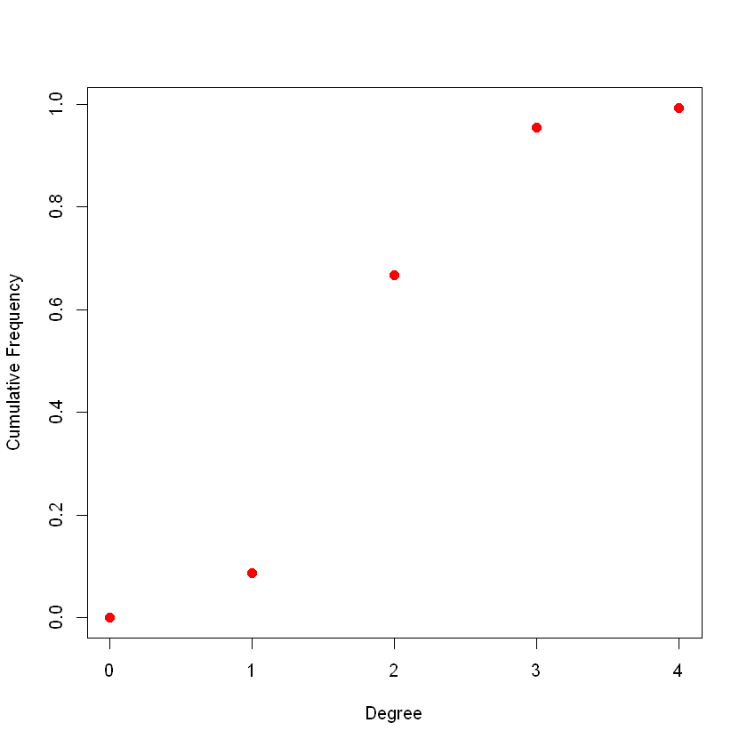

```r
plot( x=0:max(deg3), y=1-deg.dist.out, pch=19, cex=1.2, col="red",
      xlab="Degree", ylab="Cumulative Frequency")
```

The degree of a node refers to the number of ties associated with a node.

Deg1 measures all the ties going in and out. In our case, deg1 gives an output of books ids and their corresponding total number of links going to and from the focal product in the network.Degree distribution deg.dist.all shows the cumulative frequency of nodes with degree Deg1. The centralization function centr_degree returned res - vertex centrality, centralization of 0.02794058, and theoretical_max 1630818 - maximum centralization score for the newgraph.

Deg2 measures all the ties going in. In our case, deg2 gives an output of books ids and their corresponding total number of links going to the focal product in the network.Degree distribution deg.dist.in shows the cumulative frequency of nodes with degree Deg2. The centralization function centr_degree returned res - vertex centrality, centralization of 0.05725629, and theoretical_max 816312- maximum centralization score for the newgraph.

Deg3 measures all the ties going out. In our case, deg3 gives an output of books ids and their corresponding total number of links going from the focal product.Degree distribution deg.dist.out shows the cumulative frequency of nodes with degree Deg3. The centralization function centr_degree returned res - vertex centrality, centralization of 0.002992728,and theoretical_max 816312- maximum centralization score for the newgraph. We can observe that maximum centralization score for indegree and outdegree ties is the same 816312.

```r
# Density is the proportion of present edges from all possible ties. For our network, density is 0.001436951.
edge_density(newgraph, loops=F)
```

0.00143695057772028

```r
# Closeness refers to how connected a node is to its neighbors. It is inverse of the node's average geodesic distance to
# others. The higher values are the less centrality is in the network. Besides that, centralization function centr_clo
# returned centralization score of 0.1074443 and theoretical max of 451.2499 for the graph.
closeness<-closeness(newgraph, mode="all", weights=NA)
centr_clo(newgraph,mode="all",normalized=T)
```

**$res**

1. 0.0816824966078697

2. 0.0973375013474184

3. 0.0911936982427792

4. 0.0972326908581889

5. 0.127704709376326

6. 0.135098743267504

7. 0.0972117558402412

8. 0.0972326908581889

9. 0.0755585306668898

10. 0.106048150322959

11. 0.127254791431793

12. 0.143151553582752

13. 0.107538406573776

14. 0.0912121212121212

15. 0.070277842633668

16. 0.0694241562235719

17. 0.116606404958678

18. 0.0971699128376197

19. 0.113257243195786

20. 0.0730464326160815

21. 0.111715947049363

22. 0.106939838938892

23. 0.110121951219512

24. 0.117044718081659

25. 0.109880749574106

26. 0.0680687471732248

27. 0.104032258064516

28. 0.0954041204437401

29. 0.0959005947323704

30. 0.128779235596121

31. 0.120560747663551

32. 0.133540372670807

33. 0.10464712017615

34. 0.0702341137123746

35. 0.0755332496863237

36. 0.0836111111111111

37. 0.0912305516265912

38. 0.0722284434490481

39. 0.118162784611358

40. 0.0694241562235719

41. 0.0966188743847635

42. 0.082798459563543

43. 0.0680841438588555

44. 0.0440251572327044

45. 0.114159292035398

46. 0.0944560669456067

47. 0.083564686285397

48. 0.125695991091314

49. 0.12739841986456

50. 0.0682436517533253

51. 0.0731766612641815

52. 0.0482707008071845

53. 0.127147282455646

54. 0.0913320521897441

55. 0.0730346166289227

56. 0.0839297332465843

57. 0.0951227220056884

58. 0.116261104673619

59. 0.0836653386454183

60. 0.125923859991633

61. 0.0680841438588555

62. 0.140654205607477

63. 0.0911752827140549

64. 0.0682488096137858

65. 0.063911104819874

66. 0.117823590814196

67. 0.0507046998708518

68. 0.0731055699481865

69. 0.0681715234787861

70. 0.0656727272727273

71. 0.125242718446602

72. 0.113157894736842

73. 0.0656727272727273

74. 0.092416334049739

75. 0.101815311760063

76. 0.0694241562235719

77. 0.0752186588921283

78. 0.121961102106969

79. 0.0722284434490481

80. 0.096660244059088

81. 0.092968186965922

82. 0.0850682995760716

83. 0.0831032578685809

84. 0.0767596055763346

85. 0.099602911978822

86. 0.0811466570812365

87. 0.0917123705057891

88. 0.0912121212121212

89. 0.0774376125546694

90. 0.091591439294046

91. 0.056363522876225

92. 0.0506876227897839

93. 0.0730346166289227

94. 0.0806754221388368

95. 0.111965282083075

96. 0.100770003347841

97. 0.0694455125740214

98. 0.0913135807462837

99. 0.125416666666667

100. 0.113314092106914

101. 0.112945590994371

102. 0.126064498115315

103. 0.126134935046794

104. 0.113813965213007

105. 0.0639156285390713

106. 0.0911936982427792

107. 0.0911568746214415

108. 0.071293225959261

109. 0.0682384946724099

110. 0.063911104819874

111. 0.111509014571499

112. 0.091285887585928

113. 0.0682178741406663

114. 0.0682333383708629

115. 0.0850682995760716

116. 0.0850682995760716

117. 0.127218934911243

118. 0.0837118754055808

119. 0.127183098591549

120. 0.11794670846395

121. 0.088304322315666

122. 0.0902278177458034

123. 0.0600918346975444

124. 0.117915904936015

125. 0.113699320070511

126. 0.102114666968223

127. 0.0596039603960396

128. 0.127758913412564

129. 0.0600918346975444

130. 0.0566961763043888

131. 0.0482655406488856

132. 0.0699295283822504

133. 0.105527638190955

134. 0.0911568746214415

135. 0.112818590704648

136. 0.10080375083724

137. 0.127111486486486

138. 0.100199733688415

139. 0.0840860415308688

140. 0.111179512435361

141. 0.0536573771465922

142. 0.0882697947214076

143. 0.0657253075187423

144. 0.0911936982427792

145. 0.0926153846153846

146. 0.0694241562235719

147. 0.0852530211480362

148. 0.0750498670212766

149. 0.091350531107739

150. 0.0730346166289227

151. 0.0837118754055808

152. 0.105527638190955

153. 0.0730464326160815

154. 0.092350173859685

155. 0.0837118754055808

156. 0.0811320754716981

157. 0.102114666968223

158. 0.0840547333147166

159. 0.0917496443812233

160. 0.0776173285198556

161. 0.107653791130186

162. 0.124827204865911

163. 0.0650295261414374

164. 0.101437879128286

165. 0.0911936982427792

166. 0.112875

167. 0.0533845699083654

168. 0.0966188743847635

169. 0.12536443148688

170. 0.068130375735627

171. 0.112243629583592

172. 0.113857016769638

173. 0.0840547333147166

174. 0.0911936982427792

175. 0.0911568746214415

176. 0.0881491604841859

177. 0.0912951167728238

178. 0.0650295261414374

179. 0.100646455639768

180. 0.0996248896734334

181. 0.0533593334515157

182. 0.0835801554979637

183. 0.0777242210363229

184. 0.069547134935305

185. 0.087686929500874

186. 0.0923690671031097

187. 0.053390882752912

188. 0.087103308575287

189. 0.0754322947122212

190. 0.0631512693195328

191. 0.0836653386454183

192. 0.0783446121811557

193. 0.127111486486486

194. 0.0808632578131996

195. 0.0878661087866109

196. 0.0594039865798303

197. 0.0847728126173489

198. 0.0694348327566321

199. 0.0837118754055808

200. 0.10219556360344

201. 0.100950251537172

202. 0.11098820058997

203. 0.0930352359365341

204. 0.127903682719547

205. 0.0917776196767964

206. 0.0971908298353245

207. 0.125329632199861

208. 0.102369345879152

209. 0.0912121212121212

210. 0.091899043354366

211. 0.0678539224526601

212. 0.049804202746677

213. 0.0533593334515157

214. 0.0751810840063275

215. 0.056097409455178

216. 0.0748570007460831

217. 0.0914986320802513

218. 0.087103308575287

219. 0.0963302752293578

220. 0.0911936982427792

221. 0.0696544276457883

222. 0.0783310201249133

223. 0.0594274432379072

224. 0.0912397696271597

225. 0.127183098591549

226. 0.091138473960436

227. 0.0871537496380658

228. 0.0474688534931399

229. 0.0523751522533496

230. 0.0771794871794872

231. 0.0912121212121212

232. 0.123394370046461

233. 0.100927685257628

234. 0.101006711409396

235. 0.10219556360344

236. 0.123360655737705

237. 0.08417225950783

238. 0.0750873108265425

239. 0.0696490551484767

240. 0.0600918346975444

241. 0.0672575599582899

242. 0.111674499134306

243. 0.100355634585463

244. 0.125329632199861

245. 0.0836265975180589

246. 0.0838907469342252

247. 0.0730228044638525

248. 0.0836808451487351

249. 0.0836808451487351

250. 0.0776106574989257

251. 0.125347029428096

252. 0.080145557823733

253. 0.113299874529486

254. 0.0533624867036993

255. 0.0751685673853326

256. 0.123394370046461

257. 0.0976216216216216

258. 0.091591439294046

259. 0.0917123705057891

260. 0.101735015772871

261. 0.101437879128286

262. 0.0699620361044394

263. 0.127111486486486

264. 0.112875

265. 0.083564686285397

266. 0.0912489894907033

267. 0.0906080674292595

268. 0.072118840348215

269. 0.112875

270. 0.127111486486486

271. 0.0747145457554195

272. 0.125242718446602

273. 0.0836033700583279

274. 0.0992744063324538

275. 0.125242718446602

276. 0.10231135282121

277. 0.0959821428571429

278. 0.0871201157742402

279. 0.106561246164739

280. 0.10985401459854

281. 0.0839141343741288

282. 0.0776640577965081

283. 0.0721130809774796

284. 0.0928248355263158

285. 0.101666291375816

286. 0.0836265975180589

287. 0.0802025046629363

288. 0.0850682995760716

289. 0.0840703845079602

290. 0.0751810840063275

291. 0.0680687471732248

292. 0.100725041829336

293. 0.125818587153407

294. 0.0836343428730203

295. 0.102241847826087

296. 0.113356766256591

297. 0.091703056768559

298. 0.0774110587226747

299. 0.0774110587226747

300. 0.09108331652209

301. 0.127111486486486

302. 0.087103308575287

303. 0.101437879128286

304. 0.0839921867733234

305. 0.113257243195786

306. 0.100995414383179

307. 0.0836343428730203

308. 0.112903225806452

309. 0.0638252756573367

310. 0.0726585130350821

311. 0.102555366269165

312. 0.084836527621195

313. 0.112020841086714

314. 0.0911568746214415

315. 0.0563108006984285

316. 0.111674499134306

317. 0.0699295283822504

318. 0.0453381533363458

319. 0.08291249655679

320. 0.110095098756401

321. 0.111826625386997

322. 0.091304347826087

323. 0.0840312674483529

324. 0.0561043802423113

325. 0.077710843373494

326. 0.111440207330618

327. 0.109827292629531

328. 0.112875

329. 0.0699620361044394

330. 0.09173100365705

331. 0.0848444987315606

332. 0.0771399282419272

333. 0.0730228044638525

334. 0.117823590814196

335. 0.125277469478357

336. 0.125242718446602

337. 0.123360655737705

338. 0.109827292629531

339. 0.123360655737705

340. 0.0842193620593173

341. 0.081175836030205

342. 0.0836033700583279

343. 0.0811685393258427

344. 0.0836808451487351

345. 0.0655630581572642

346. 0.127183098591549

347. 0.0927009547274407

348. 0.123326959847036

349. 0.0974951414381343

350. 0.0901737567405632

351. 0.0915079043372517

352. 0.117854346123727

353. 0.102045428862018

354. 0.0751810840063275

355. 0.0730228044638525

356. 0.0916379135376497

357. 0.0774907749077491

358. 0.0839765646796243

359. 0.0903722978382706

360. 0.0829048843187661

361. 0.112875

362. 0.11134401972873

363. 0.125242718446602

364. 0.0672575599582899

365. 0.0720958083832335

366. 0.123326959847036

367. 0.123326959847036

368. 0.0783310201249133

369. 0.0720958083832335

370. 0.0720842979165004

371. 0.100590397682968

372. 0.0848524713399737

373. 0.0848763981577216

374. 0.0836808451487351

375. 0.100646455639768

376. 0.0771926825098307

377. 0.0926819254849636

378. 0.077404423109892

379. 0.112875

380. 0.0630322490576574

381. 0.087103308575287

382. 0.0658499234303216

383. 0.0930448222565688

384. 0.08417225950783

385. 0.0848524713399737

386. 0.0920114122681883

387. 0.0811685393258427

388. 0.0848843767625494

389. 0.109934258582907

390. 0.0914245216158753

391. 0.0720095693779904

392. 0.0888342351205116

393. 0.0804167779855731

394. 0.113285660519383

395. 0.0941017090454356

396. 0.0917123705057891

397. 0.0835801554979637

398. 0.087103308575287

399. 0.0881922062701436

400. 0.0911936982427792

401. 0.0771794871794872

402. 0.0469823100936524

403. 0.0930735930735931

404. 0.113785282258065

405. 0.0839609483960948

406. 0.0885902089669381

407. 0.049242011124441

408. 0.0835956304388076

409. 0.0775573305849008

410. 0.0751685673853326

411. 0.10219556360344

412. 0.123326959847036

413. 0.123529411764706

414. 0.0399363141833621

415. 0.127183098591549

416. 0.10985401459854

417. 0.127111486486486

418. 0.0919177524429967

419. 0.0990783410138249

420. 0.117885117493473

421. 0.0699295283822504

422. 0.102056962025316

423. 0.10985401459854

424. 0.127111486486486

425. 0.09596174282678

426. 0.105936180197091

427. 0.0721130809774796

428. 0.0882266731802638

429. 0.107602478551001

430. 0.095434369055168

431. 0.0776373484653082

432. 0.0930352359365341

433. 0.11134401972873

434. 0.105490654205607

435. 0.090155750798722

436. 0.109934258582907

437. 0.123326959847036

438. 0.0616929698708752

439. 0.065744448489261

440. 0.127183098591549

441. 0.0839921867733234

442. 0.105515307314793

443. 0.11139896373057

444. 0.0701577189029601

445. 0.0982375979112272

446. 0.0959005947323704

447. 0.0971699128376197

448. 0.0974951414381343

449. 0.127111486486486

450. 0.0775706554419723

451. 0.0911936982427792

452. 0.0963097269624573

453. 0.119160728424386

454. 0.123326959847036

455. 0.0469627626378198

456. 0.0678539224526601

457. 0.109880749574106

458. 0.0990131578947368

459. 0.127183098591549

460. 0.101769412825425

461. 0.123647815966041

462. 0.100848782666964

463. 0.0888604605392639

464. 0.0784262636789995

465. 0.0916286149162862

466. 0.0917682926829268

467. 0.125277469478357

468. 0.111993054694283

469. 0.100927685257628

470. 0.123326959847036

471. 0.127111486486486

472. 0.123495623632385

473. 0.0917123705057891

474. 0.0928630193336076

475. 0.123326959847036

476. 0.123326959847036

477. 0.0678539224526601

478. 0.0843452269755277

479. 0.0926629040533607

480. 0.0630322490576574

481. 0.113456464379947

482. 0.0847728126173489

483. 0.0618874648756082

484. 0.091350531107739

485. 0.0837429286840397

486. 0.077583984878426

487. 0.0649500107890383

488. 0.077087246030391

489. 0.112846788302924

490. 0.0696544276457883

491. 0.0917682926829268

492. 0.127758913412564

493. 0.103864734299517

494. 0.0929777594728171

495. 0.123394370046461

496. 0.113044566850275

497. 0.0583672677913516

498. 0.0836188535975553

499. 0.110216038081289

500. 0.0448963357032765

501. 0.0992744063324538

502. 0.0782563480370916

503. 0.101437879128286

504. 0.0684921116504854

505. 0.0672575599582899

506. 0.0672575599582899

507. 0.105490654205607

508. 0.0917496443812233

509. 0.0782766990291262

510. 0.0533624867036993

511. 0.113527784762384

512. 0.105441382531527

513. 0.0750873108265425

514. 0.0917123705057891

515. 0.0836111111111111

516. 0.0637531770686247

517. 0.0680892776353491

518. 0.100646455639768

519. 0.123326959847036

520. 0.109934258582907

521. 0.123495623632385

522. 0.0448896400874925

523. 0.112973852120606

524. 0.08417225950783

525. 0.0523356902747189

526. 0.0440294504851529

527. 0.127111486486486

528. 0.0720095693779904

529. 0.0694348327566321

530. 0.0775506698728959

531. 0.112048641270629

532. 0.071293225959261

533. 0.0448762548454428

534. 0.060457953936797

535. 0.108040201005025

536. 0.0718491406747295

537. 0.123326959847036

538. 0.112846788302924

539. 0.0974951414381343

540. 0.11098820058997

541. 0.0975161987041037

542. 0.0992853216052776

543. 0.109987819732034

544. 0.0847728126173489

545. 0.123326959847036

546. 0.110108523350811

547. 0.0771531100478469

548. 0.0783310201249133

549. 0.117823590814196

550. 0.0847728126173489

551. 0.105539971949509

552. 0.0744496660895375

553. 0.125242718446602

554. 0.09108331652209

555. 0.0847728126173489

556. 0.0836963574010566

557. 0.101460674157303

558. 0.0632087358252835

559. 0.0542212081181698

560. 0.100770003347841

561. 0.0835956304388076

562. 0.092786683107275

563. 0.0727287371134021

564. 0.084996234939759

565. 0.0638252756573367

566. 0.0840625581828337

567. 0.123597043525869

568. 0.125329632199861

569. 0.0776240006876988

570. 0.0841330476101742

571. 0.077630674002751

572. 0.110054844606947

573. 0.0384042869901756

574. 0.0840782122905028

575. 0.127111486486486

576. 0.123326959847036

577. 0.0673428294429115

578. 0.0777442961687473

579. 0.0928248355263158

580. 0.0517122895430077

581. 0.0638252756573367

582. 0.0696275734443673

583. 0.104164263467528

584. 0.101437879128286

585. 0.111965282083075

586. 0.068752855185016

587. 0.0544303797468354

588. 0.0917123705057891

589. 0.0917496443812233

590. 0.0748321869561614

591. 0.123326959847036

592. 0.080625

593. 0.109827292629531

594. 0.111854329245634

595. 0.109880749574106

596. 0.101540537501406

597. 0.123394370046461

598. 0.0677013045434098

599. 0.0694348327566321

600. 0.0562616822429907

601. 0.110014619883041

602. 0.114101592115239

603. 0.0684921116504854

604. 0.091591439294046

605. 0.0807764558547276

606. 0.123326959847036

607. 0.0645368782161235

608. 0.0643437366395896

609. 0.0811174991016888

610. 0.123360655737705

611. 0.112875

612. 0.0523356902747189

613. 0.0574427480916031

614. 0.0886510897310033

615. 0.0814393939393939

616. 0.0772785622593068

617. 0.0993399339933993

618. 0.114101592115239

619. 0.125242718446602

620. 0.127183098591549

621. 0.0827832783278328

622. 0.0914708265802269

623. 0.114101592115239

624. 0.0673026757099203

625. 0.0721534159009189

626. 0.0842507930584064

627. 0.127111486486486

628. 0.111426456071076

629. 0.0807764558547276

630. 0.102450646698434

631. 0.0573260538344337

632. 0.123461853978671

633. 0.0692962934540711

634. 0.111674499134306

635. 0.0835956304388076

636. 0.0993508636813731

637. 0.123461853978671

638. 0.0448807157057654

639. 0.099110964767863

640. 0.099110964767863

641. 0.0903722978382706

642. 0.123326959847036

643. 0.127111486486486

644. 0.0841017043867002

645. 0.114130434782609

646. 0.0975372650680493

647. 0.127111486486486

648. 0.109827292629531

649. 0.0921898928024502

650. 0.123326959847036

651. 0.0991653854601362

652. 0.0691371257943496

653. 0.0829277252272936

654. 0.123326959847036

655. 0.095474730386974

656. 0.112818590704648

657. 0.112903225806452

658. 0.0720612880057458

659. 0.123580128643766

660. 0.0829277252272936

661. 0.0635557432432432

662. 0.0678641214489704

663. 0.0448762548454428

664. 0.0811102128806252

665. 0.108716590416566

666. 0.0720440402106271

667. 0.0829048843187661

668. 0.0903903903903904

669. 0.0902458524885069

670. 0.0429549995243079

671. 0.0777309115950762

672. 0.123326959847036

673. 0.0929012345679012

674. 0.0841879545030766

675. 0.101472075514103

676. 0.112917344004001

677. 0.0848843767625494

678. 0.127111486486486

679. 0.123326959847036

680. 0.0764735772357724

681. 0.0847728126173489

682. 0.0722284434490481

683. 0.109961032635168

684. 0.10066889632107

685. 0.102265005662514

686. 0.127111486486486

687. 0.0532680509674375

688. 0.0649313295462717

689. 0.0783310201249133

690. 0.087874659400545

691. 0.0469554365347616

692. 0.0776573787409701

693. 0.127147282455646

694. 0.0911568746214415

695. 0.111993054694283

696. 0.0789611752360965

697. 0.127183098591549

698. 0.127111486486486

699. 0.114101592115239

700. 0.123326959847036

701. 0.0783310201249133

702. 0.0694348327566321

703. 0.0903361344537815

704. 0.0926914391295422

705. 0.0412046543463381

706. 0.064940668824164

707. 0.123360655737705

708. 0.114101592115239

709. 0.0972012917115178

710. 0.0911568746214415

711. 0.0573187761838263

712. 0.0776106574989257

713. 0.0917682926829268

714. 0.0783446121811557

715. 0.127218934911243

716. 0.127147282455646

717. 0.11002802485683

718. 0.0638252756573367

719. 0.0783310201249133

720. 0.123326959847036

721. 0.100725041829336

722. 0.127111486486486

723. 0.109934258582907

724. 0.068130375735627

725. 0.112201789264414

726. 0.0836265975180589

727. 0.0771794871794872

728. 0.110054844606947

729. 0.0840625581828337

730. 0.123326959847036

731. 0.0972012917115178

732. 0.111674499134306

733. 0.0448584202682563

734. 0.0429733974206444

735. 0.127111486486486

736. 0.114101592115239

737. 0.0826468973091708

738. 0.127111486486486

739. 0.0890356931571682

740. 0.112875

741. 0.075043630017452

742. 0.0730228044638525

743. 0.114101592115239

744. 0.101437879128286

745. 0.127183098591549

746. 0.0992962392786453

747. 0.109827292629531

748. 0.0850122387497646

749. 0.0801882603676405

750. 0.127111486486486

751. 0.0807909099042677

752. 0.0747578441924

753. 0.111965282083075

754. 0.127111486486486

755. 0.0818231243204059

756. 0.0668097070139094

757. 0.127147282455646

758. 0.112818590704648

759. 0.076344267839026

760. 0.114130434782609

761. 0.127111486486486

762. 0.112818590704648

763. 0.0617140513942045

764. 0.065768390386016

765. 0.127111486486486

766. 0.0415918198148404

767. 0.0429713524317122

768. 0.0722284434490481

769. 0.0992853216052776

770. 0.075678846798525

771. 0.119444444444444

772. 0.0850682995760716

773. 0.0810810810810811

774. 0.111965282083075

775. 0.076570847112694

776. 0.114130434782609

777. 0.0842350746268657

778. 0.070381917381138

779. 0.127147282455646

780. 0.125242718446602

781. 0.100646455639768

782. 0.0783310201249133

783. 0.0850122387497646

784. 0.100590397682968

785. 0.123495623632385

786. 0.0924636493958632

787. 0.0917496443812233

788. 0.141869599371563

789. 0.0672876304023845

790. 0.112818590704648

791. 0.127147282455646

792. 0.127111486486486

793. 0.127111486486486

794. 0.114101592115239

795. 0.127111486486486

796. 0.114101592115239

797. 0.114101592115239

798. 0.0921052631578947

799. 0.101964769647696

800. 0.0881491604841859

801. 0.123326959847036

802. 0.0491722936179482

803. 0.0850362557679631

804. 0.0957988542329726

805. 0.123326959847036

806. 0.085052274653857

807. 0.0746774727092292

808. 0.111965282083075

809. 0.102010845006778

810. 0.111895910780669

811. 0.123360655737705

812. 0.0783990276089599

813. 0.0925868963395878

814. 0.0925868963395878

815. 0.0783990276089599

816. 0.109827292629531

817. 0.0783310201249133

818. 0.123360655737705

819. 0.127111486486486

820. 0.0888867014469928

821. 0.0888867014469928

822. 0.0991436100131752

823. 0.0902278177458034

824. 0.112875

825. 0.127183098591549

826. 0.101437879128286

827. 0.107615302109403

828. 0.100288760550866

829. 0.145598194130926

830. 0.0745972738537794

831. 0.078768318213538

832. 0.0991000877963126

833. 0.0871705763104547

834. 0.0778448275862069

835. 0.0764735772357724

836. 0.046050283033301

837. 0.102497162315551

838. 0.100333333333333

839. 0.0460549803641557

840. 0.0841330476101742

841. 0.0871705763104547

842. 0.0812708127081271

843. 0.090065828845003

844. 0.100961538461538

845. 0.0836265975180589

846. 0.064940668824164

847. 0.0506990062321038

848. 0.0703435382098621

849. 0.0680687471732248

850. 0.111895910780669

851. 0.0721361239814667

852. 0.0806970509383378

853. 0.0845663982019105

854. 0.0594039865798303

855. 0.0849802371541502

856. 0.08417225950783

857. 0.0727873609543769

858. 0.0552192258301229

859. 0.10985401459854

860. 0.108014354066986

861. 0.07426597582038

862. 0.102590320381731

863. 0.043386345072791

864. 0.0531270224157204

865. 0.100277623542476

866. 0.0782156777825899

867. 0.071621192893401

868. 0.0750873108265425

869. 0.0991000877963126

870. 0.101437879128286

871. 0.0672425348127187

872. 0.0716666666666667

873. 0.0672675804529201

874. 0.0771531100478469

875. 0.0616929698708752

876. 0.0954545454545455

877. 0.0772785622593068

878. 0.0715871254162042

879. 0.117059891107078

880. 0.101574803149606

881. 0.11020258725897

882. 0.0725825898239691

883. 0.0735222276502198

884. 0.0840625581828337

885. 0.0726117722740431

886. 0.0849163061876998

887. 0.0783446121811557

888. 0.0775639924411613

889. 0.0990131578947368

890. 0.0607998922704013

891. 0.109987819732034

892. 0.0904175428056473

893. 0.0672225117248567

894. 0.0726585130350821

895. 0.0991327258755077

896. 0.100893854748603

897. 0.101437879128286

898. 0.0698105914186316

899. 0.112875

900. 0.102450646698434

901. 0.102450646698434

902. 0.112818590704648

903. 0.109827292629531

904. 0.0827681026581118

**$centralization**

0.107444307026948

**$theoretical_max**

451.249861495845

```r
# Betweenness is the number of shortest paths between two nodes that go through each node of interest. Betweenness
# calculates vertex betweenness, edge_betweenness calculates edge betweenness. Vertix 2501 has a high betweenness 298
# which indicates that it has a considerable influence within a network due to its control over information passing
# between others. Its removal from the network may disrupt communications between other vertices because it lies on the
# largest number of paths. Its centralization function also returns centralization score of 0.0003616307 and theoretical
# max of 735498918.
betweenness<-betweenness(newgraph, directed=T, weights=NA)
edge_betweenness(newgraph,directed = T, weights=NA)
```

1. 16

2. 2

3. 3

4. 2

5. 1

6. 2

7. 42

8. 6

9. 27

10. 1

11. 1

12. 1

13. 1

14. 2

15. 2

16. 4

17. 15

18. 5

19. 5

20. 32

21. 2

22. 3

23. 6

24. 12

25. 1

26. 3

27. 2

28. 1

29. 3

30. 3

31. 6

32. 20

33. 15

34. 16

35. 18

36. 15

37. 6

38. 24

39. 16

40. 2

41. 10

42. 2

43. 20

44. 2

45. 300

46. 48

47. 23

48. 2

49. 6

50. 6

51. 10

52. 2

53. 5

54. 1

55. 8

56. 1

57. 10

58. 3

59. 2

60. 1

61. 1

62. 1

63. 151

64. 2

65. 1

66. 2

67. 12

68. 7

69. 2

70. 14

71. 1

72. 4

73. 2

74. 2.5

75. 2.5

76. 2

77. 1

78. 16

79. 2

80. 9

81. 3

82. 3

83. 3

84. 21

85. 7

86. 2

87. 263

88. 2

89. 7

90. 10

91. 6

92. 17

93. 15

94. 2

95. 6

96. 8

97. 10

98. 3

99. 7

100. 2

101. 10

102. 3

103. 1

104. 5

105. 1

106. 8

107. 1

108. 4

109. 6

110. 1

111. 12

112. 6

113. 2

114. 4

115. 5

116. 6

117. 4

118. 1

119. 1

120. 2

121. 1

122. 1

123. 1

124. 9

125. 21

126. 8

127. 6

128. 2

129. 2

130. 1

131. 25

132. 1

133. 24

134. 1.5

135. 2

136. 2

137. 1.5

138. 1.5

139. 8

140. 12

141. 9

142. 2

143. 31

144. 9

145. 30

146. 10

147. 24

148. 15

149. 14

150. 2

151. 1

152. 3

153. 5

154. 10

155. 16

156. 1

157. 15

158. 7

159. 7

160. 2

161. 7

162. 2

163. 18

164. 2

165. 1

166. 4

167. 3

168. 2

169. 2

170. 1

171. 10

172. 7

173. 7

174. 2

175. 1

176. 8

177. 4

178. 6

179. 6

180. 8

181. 3

182. 4

183. 14

184. 15

185. 12

186. 1

187. 1

188. 1

189. 2

190. 3

191. 4

192. 1

193. 2

194. 7

195. 1

196. 42

197. 2

198. 1

199. 42

200. 7

201. 4

202. 4

203. 1

204. 1

205. 8

206. 9

207. 1

208. 4

209. 4

210. 4

211. 4

212. 1

213. 1

214. 3

215. 4

216. 3

217. 4

218. 3

219. 6

220. 3

221. 1

222. 2

223. 2

224. 2

225. 3

226. 3

227. 1

228. 12

229. 40

230. 10

231. 4

232. 1

233. 1

234. 2

235. 2

236. 1

237. 10

238. 5

239. 2

240. 30

241. 6

242. 4

243. 1

244. 2

245. 3

246. 1

247. 2

248. 1

249. 1

250. 4

251. 1

252. 1

253. 2

254. 2

255. 2

256. 2

257. 2

258. 2

259. 2

260. 6

261. 3

262. 5

263. 1

264. 6

265. 4

266. 2

267. 3

268. 3

269. 5

270. 1

271. 3

272. 1

273. 2

274. 1

275. 12

276. 24

277. 16

278. 20

279. 8

280. 2

281. 3

282. 2

283. 3

284. 3

285. 12

286. 6

287. 5

288. 13

289. 2

290. 2

291. 2

292. 1

293. 7

294. 2

295. 6

296. 4

297. 4

298. 10

299. 10

300. 1

301. 3

302. 2

303. 2

304. 2

305. 5

306. 10

307. 11

308. 5

309. 5

310. 2

311. 12

312. 1

313. 2

314. 1

315. 4

316. 1

317. 4

318. 2

319. 2

320. 3

321. 24

322. 1

323. 4

324. 2

325. 4

326. 2

327. 1

328. 7

329. 12

330. 6

331. 14

332. 1.5

333. 6.5

334. 8

335. 3

336. 4

337. 2

338. 4

339. 4

340. 1

341. 2

342. 3

343. 12

344. 2

345. 1

346. 1

347. 4

348. 10

349. 10

350. 1

351. 3

352. 1.5

353. 1.5

354. 3

355. 1

356. 1

357. 1.5

358. 12

359. 4

360. 6

361. 3

362. 2

363. 2

364. 1

365. 8

366. 2

367. 3

368. 1

369. 1

370. 9

371. 2

372. 1

373. 2

374. 1

375. 2

376. 18

377. 1

378. 2

379. 2

380. 2

381. 3

382. 10

383. 4

384. 1

385. 4

386. 2

387. 5

388. 6

389. 3

390. 2

391. 9

392. 9

393. 2

394. 2

395. 4

396. 2

397. 3

398. 16

399. 6

400. 1

401. 4

402. 1

403. 27

404. 27

405. 18

406. 5

407. 7

408. 3

409. 4

410. 3

411. 2

412. 2

413. 72

414. 35

415. 2

416. 2

417. 6

418. 12

419. 4

420. 1

421. 6

422. 32

423. 32

424. 7

425. 1

426. 1

427. 1

428. 1

429. 8

430. 1

431. 2

432. 3

433. 7

434. 4

435. 3

436. 3

437. 6

438. 2

439. 1

440. 4

441. 3

442. 2

443. 12

444. 4

445. 8

446. 6

447. 5

448. 1

449. 1

450. 1

451. 3

452. 2

453. 1

454. 3

455. 2

456. 2

457. 10

458. 15

459. 2

460. 3

461. 1

462. 2

463. 3

464. 12

465. 3

466. 1

467. 5

468. 2

469. 2

470. 2

471. 12

472. 7

473. 10

474. 1

475. 1

476. 2

477. 4

478. 2

479. 8

480. 5

481. 8

482. 12

483. 4

484. 2

485. 4

486. 1

487. 3

488. 1

489. 3

490. 1

491. 1

492. 1.5

493. 4

494. 2

495. 1

496. 5

497. 4

498. 1

499. 1

500. 24

501. 10

502. 7

503. 7

504. 4

505. 4

506. 4

507. 2

508. 1

509. 8

510. 3

511. 5

512. 4

513. 3

514. 2

515. 2

516. 1

517. 1

518. 2

519. 3

520. 2

521. 1

522. 2

523. 10

524. 10

525. 4

526. 4

527. 1

528. 10

529. 10

530. 10

531. 6

532. 2

533. 1

534. 2

535. 3

536. 1

537. 1

538. 1

539. 1

540. 3

541. 1

542. 12

543. 25

544. 5

545. 3

546. 4

547. 1

548. 2

549. 3

550. 3

551. 2

552. 5

553. 1

554. 3

555. 2

556. 1

557. 4

558. 2

559. 3

560. 4

561. 1

562. 5

563. 15

564. 1

565. 18

566. 5

567. 2

568. 3

569. 3

570. 6

571. 1

572. 3

573. 1

574. 2

575. 2

576. 2

577. 1

578. 1

579. 1

580. 10

581. 10

582. 24

583. 4

584. 1.5

585. 6

586. 1.5

587. 10

588. 5

589. 2

590. 15.5

591. 6

592. 2

593. 1

594. 16

595. 1

596. 3

597. 4

598. 12

599. 2

600. 1

601. 3

602. 5

603. 1

604. 14

605. 1

606. 12

607. 2

608. 2

609. 2

610. 63

611. 12

612. 5

613. 1

614. 2

615. 4

616. 9

617. 5

618. 8

619. 4

620. 4

621. 1

622. 2

623. 5

624. 2

625. 3

626. 2

627. 7

628. 12

629. 3

630. 4

631. 3

632. 2

633. 2

634. 1

635. 3

636. 12

637. 1

638. 3

639. 1

640. 6

641. 6

642. 1

643. 1

644. 1

645. 2

646. 1

647. 1

648. 1

649. 1

650. 2

651. 1

652. 6

653. 15

654. 4

655. 6

656. 2

657. 1

658. 1

659. 10

660. 6

661. 2

662. 1

663. 4

664. 28

665. 5

666. 1

667. 2

668. 1

669. 2

670. 2

671. 2

672. 4

673. 4

674. 4

675. 1

676. 10

677. 6

678. 4

679. 1

680. 16

681. 1

682. 8

683. 4

684. 4

685. 1

686. 3

687. 3

688. 15

689. 1

690. 6

691. 3

692. 3

693. 4

694. 4

695. 3

696. 3

697. 6

698. 2

699. 48

700. 1

701. 2

702. 2.5

703. 1.5

704. 4

705. 2

706. 1

707. 2

708. 2

709. 1

710. 6

711. 16

712. 4

713. 1

714. 6

715. 1

716. 12

717. 2

718. 1

719. 3

720. 3

721. 3

722. 20

723. 3

724. 11

725. 16

726. 1

727. 2

728. 1

729. 3

730. 1

731. 1

732. 1

733. 1

734. 1

735. 3

736. 1

737. 1

738. 3

739. 2

740. 1

741. 10

742. 3

743. 2

744. 2

745. 1

746. 2

747. 3

748. 4

749. 1

750. 1

751. 4

752. 8

753. 24

754. 6

755. 4.5

756. 1

757. 6

758. 3

759. 3

760. 1

761. 1

762. 1

763. 1

764. 1

765. 17

766. 1.5

767. 1

768. 10

769. 4

770. 5

771. 5

772. 1

773. 1

774. 2

775. 4

776. 2

777. 1

778. 6

779. 2

780. 6

781. 5

782. 1

783. 1

784. 3

785. 4

786. 2.5

787. 6.5

788. 3

789. 1

790. 2

791. 3

792. 10

793. 1

794. 6

795. 1

796. 2

797. 8

798. 3

799. 3

800. 3

801. 2

802. 1

803. 2

804. 6

805. 4

806. 4

807. 1

808. 3

809. 5

810. 3

811. 3

812. 4

813. 1

814. 3

815. 1

816. 1

817. 4

818. 15

819. 6

820. 2

821. 8

822. 1

823. 5

824. 1

825. 3

826. 9

827. 1

828. 4

829. 2

830. 6

831. 3

832. 15

833. 7

834. 20

835. 6

836. 3

837. 9

838. 6

839. 3

840. 5

841. 6

842. 4

843. 4

844. 12

845. 6

846. 1

847. 2

848. 16

849. 4

850. 2

851. 5

852. 5

853. 5

854. 2

855. 8

856. 1

857. 8

858. 2

859. 1

860. 1.5

861. 4

862. 20

863. 6

864. 3

865. 1

866. 1

867. 1

868. 8

869. 4

870. 4

871. 4

872. 3

873. 8

874. 3

875. 8

876. 1

877. 4

878. 1

879. 7

880. 4

881. 4

882. 4

883. 1

884. 5

885. 5

886. 3

887. 4

888. 3

889. 2

890. 1

891. 3

892. 8

893. 2

894. 3

895. 7

896. 12

897. 15

898. 2

899. 4

900. 1

901. 2

902. 2

903. 8

904. 4

905. 2

906. 4

907. 1

908. 4

909. 3

910. 4

911. 1

912. 7

913. 1

914. 9.5

915. 10

916. 1

917. 1

918. 1

919. 2

920. 4

921. 1

922. 3

923. 2

924. 6

925. 1

926. 3

927. 1

928. 5

929. 5

930. 4

931. 18

932. 4

933. 1

934. 1

935. 4

936. 6

937. 2

938. 1

939. 6

940. 2

941. 1

942. 6.5

943. 7

944. 4

945. 1

946. 2

947. 2

948. 5

949. 8

950. 3

951. 6

952. 4

953. 6

954. 1

955. 14

956. 6

957. 2

958. 4

959. 4

960. 7

961. 6

962. 1

963. 4

964. 6

965. 4

966. 15

967. 1

968. 4

969. 2

970. 3

971. 1

972. 5

973. 1

974. 1

975. 2

976. 3

977. 2

978. 1

979. 3

980. 2

981. 1

982. 7

983. 2.5

984. 2.5

985. 4

986. 1

987. 2

988. 1

989. 10

990. 1

991. 3

992. 1

993. 2

994. 2

995. 1

996. 3

997. 4

998. 1

999. 2

1000. 1.5

1001. 2

1002. 28

1003. 3

1004. 6

1005. 2.5

1006. 1.5

1007. 8

1008. 1

1009. 3

1010. 5

1011. 1

1012. 1

1013. 5

1014. 4

1015. 1

1016. 1

1017. 1

1018. 1

1019. 1

1020. 4

1021. 1

1022. 2

1023. 6

1024. 3

1025. 3

1026. 1

1027. 4

1028. 6

1029. 1

1030. 5

1031. 2

1032. 3

1033. 3

1034. 1

1035. 4

1036. 1

1037. 3

1038. 5

1039. 3

1040. 4

1041. 5

1042. 3

1043. 5

1044. 10

1045. 1

1046. 3

1047. 1

1048. 2

1049. 1

1050. 4

1051. 3

1052. 2

1053. 2

1054. 5

1055. 1

1056. 1

1057. 3

1058. 1

1059. 1

1060. 1

1061. 2

1062. 5

1063. 1

1064. 1

1065. 1

1066. 16

1067. 1

1068. 9

1069. 5

1070. 1

1071. 3

1072. 4

1073. 1

1074. 1

1075. 2

1076. 2

1077. 2

1078. 3

1079. 1

1080. 1

1081. 2

1082. 3

1083. 1

1084. 4

1085. 1

1086. 2

1087. 1

1088. 2.5

1089. 2.5

1090. 1

1091. 7

1092. 3

1093. 2

1094. 1

1095. 2

1096. 4

1097. 5

1098. 3

1099. 3

1100. 1

1101. 2

1102. 3

1103. 3

1104. 1

1105. 1

1106. 2

1107. 1

1108. 1

1109. 2

1110. 7

1111. 4

1112. 1

1113. 2

1114. 1

1115. 1

1116. 2

1117. 2

1118. 4

1119. 1

1120. 2

1121. 1

1122. 2

1123. 1

1124. 1

1125. 3

1126. 1

1127. 3

1128. 3

1129. 1

1130. 1

1131. 3

1132. 2

1133. 4

1134. 9

1135. 2

1136. 3

1137. 4

1138. 4

1139. 6

1140. 4

1141. 1

1142. 5

1143. 9

1144. 2

1145. 3

1146. 2

1147. 4

1148. 1

1149. 3

1150. 3

1151. 4

1152. 1

1153. 4

1154. 2

1155. 3

1156. 1

1157. 5

1158. 1

1159. 8

1160. 1

1161. 1

1162. 2

1163. 1

1164. 2

1165. 1

1166. 2

1167. 1

1168. 2

1169. 4

1170. 2

1171. 2

1172. 3

1173. 3

```r
centr_betw(newgraph,directed = T,normalized=T)
```

**$res**

1. 12

2. 1

3. 2

4. 2

5. 40

6. 31

7. 0

8. 2

9. 15

10. 4

11. 4

12. 31

13. 1

14. 2

15. 14

16. 0

17. 0

18. 0

19. 0

20. 2

21. 17

22. 22

23. 15

24. 12

25. 37

26. 0

27. 9

28. 19

29. 0

30. 298

31. 45

32. 22

33. 0

34. 0

35. 5

36. 0

37. 4

38. 0

39. 6

40. 0

41. 0

42. 2

43. 0

44. 0

45. 150

46. 0

47. 0

48. 10

49. 6

50. 0

51. 13

52. 3

53. 1

54. 3

55. 1

56. 8

57. 1

58. 10

59. 0

60. 24

61. 0

62. 260

63. 1

64. 31

65. 6

66. 0

67. 4

68. 7

69. 8

70. 6

71. 0

72. 8

73. 0

74. 0

75. 4

76. 0

77. 3

78. 4

79. 0

80. 11

81. 5

82. 0

83. 6

84. 7

85. 0

86. 0

87. 0

88. 0

89. 0

90. 14

91. 7

92. 0

93. 1

94. 0

95. 20

96. 18

97. 1.5

98. 1

99. 16

100. 6

101. 0

102. 36

103. 36

104. 22

105. 20

106. 1

107. 0

108. 0

109. 12

110. 12

111. 10

112. 12

113. 0

114. 11

115. 0

116. 0

117. 3

118. 1

119. 0

120. 13

121. 6

122. 0

123. 9

124. 4

125. 6

126. 0

127. 3

128. 13

129. 10

130. 6

131. 0

132. 0

133. 3

134. 0

135. 0

136. 6

137. 0

138. 35

139. 1

140. 36

141. 0

142. 6

143. 0

144. 0

145. 15

146. 0

147. 2

148. 0

149. 6

150. 0

151. 0

152. 0

153. 2

154. 0

155. 0

156. 3

157. 0

158. 1

159. 2

160. 0

161. 8

162. 45

163. 0

164. 0

165. 0

166. 1

167. 0

168. 0

169. 3

170. 0

171. 25

172. 5

173. 0

174. 2

175. 0

176. 0

177. 0

178. 0

179. 0

180. 2

181. 0

182. 0

183. 1

184. 6

185. 2

186. 0

187. 5

188. 0

189. 4

190. 4

191. 0

192. 1

193. 0

194. 29

195. 37

196. 0

197. 0

198. 1

199. 0

200. 0

201. 6

202. 0

203. 0

204. 12

205. 1

206. 1

207. 6

208. 0

209. 5

210. 18

211. 0

212. 0

213. 0

214. 1

215. 0

216. 19

217. 8

218. 0

219. 6

220. 0

221. 0

222. 0

223. 4

224. 2

225. 2

226. 16

227. 2

228. 2

229. 1

230. 0

231. 0

232. 8

233. 0

234. 13

235. 3

236. 4

237. 0

238. 0

239. 0

240. 0

241. 0

242. 0

243. 6

244. 0

245. 0

246. 18

247. 0

248. 0

249. 0.5

250. 8

251. 5

252. 0

253. 0

254. 0

255. 0

256. 5

257. 2

258. 0

259. 0

260. 7

261. 0

262. 0

263. 0

264. 0

265. 9

266. 3

267. 0

268. 5

269. 2

270. 0

271. 3

272. 0

273. 2

274. 0

275. 0

276. 12

277. 0

278. 2

279. 15

280. 0

281. 2

282. 64

283. 0

284. 0

285. 0

286. 2

287. 1

288. 0

289. 92

290. 1

291. 0

292. 0

293. 12

294. 0

295. 3

296. 56

297. 0

298. 0

299. 0

300. 0

301. 0

302. 0

303. 0

304. 9

305. 0

306. 0

307. 0

308. 2

309. 0

310. 0

311. 12

312. 0

313. 0

314. 0

315. 0

316. 0

317. 0

318. 2

319. 2

320. 5

321. 11

322. 2

323. 0

324. 2

325. 8

326. 0

327. 0

328. 1

329. 0

330. 1

331. 6

332. 0

333. 0

334. 0

335. 2

336. 0

337. 4

338. 0

339. 4

340. 9

341. 3

342. 2

343. 1

344. 0.5

345. 0

346. 0

347. 4

348. 0

349. 0

350. 0

351. 33

352. 2

353. 2

354. 1

355. 0

356. 6

357. 0

358. 2

359. 2

360. 0

361. 1

362. 0

363. 0

364. 1

365. 18

366. 0

367. 0

368. 0

369. 18

370. 9

371. 0

372. 0

373. 1

374. 0

375. 0

376. 0

377. 29

378. 0

379. 2

380. 0

381. 0

382. 2

383. 1

384. 0

385. 0

386. 3

387. 1

388. 0

389. 0

390. 0

391. 0

392. 0

393. 4

394. 3

395. 0

396. 0

397. 0

398. 0

399. 0

400. 0

401. 0

402. 40

403. 0.5

404. 4.5

405. 0

406. 0

407. 17.5

408. 0

409. 0

410. 0

411. 0

412. 0

413. 8

414. 1

415. 2

416. 0

417. 0

418. 12

419. 6

420. 0

421. 0

422. 62

423. 0

424. 0

425. 0

426. 6

427. 0

428. 9

429. 0

430. 0

431. 1

432. 0

433. 0

434. 1

435. 0

436. 10

437. 0

438. 0

439. 2

440. 2

441. 9

442. 0

443. 0

444. 3

445. 0

446. 0

447. 0

448. 0

449. 0

450. 0

451. 0

452. 0

453. 12

454. 0

455. 4

456. 0

457. 5

458. 0

459. 0

460. 0

461. 24

462. 0

463. 0

464. 2

465. 0

466. 2

467. 2

468. 5

469. 0

470. 0

471. 0

472. 12

473. 0

474. 6

475. 0

476. 0

477. 0

478. 2

479. 5

480. 0

481. 3

482. 0

483. 4

484. 4

485. 4

486. 33

487. 0

488. 0

489. 0

490. 0

491. 18

492. 0

493. 4

494. 0

495. 8

496. 0

497. 2

498. 0

499. 17

500. 23

501. 0

502. 0

503. 0

504. 0

505. 0

506. 0

507. 0

508. 0

509. 2

510. 0

511. 8

512. 0

513. 0

514. 0

515. 0

516. 0

517. 2

518. 0

519. 0

520. 0

521. 23

522. 1.5

523. 6

524. 0

525. 0

526. 0

527. 0

528. 0

529. 0.5

530. 0

531. 5

532. 0

533. 0

534. 0

535. 0

536. 1

537. 0

538. 0

539. 0

540. 0

541. 1

542. 0

543. 0

544. 0

545. 0

546. 0

547. 0

548. 0

549. 0

550. 0

551. 5

552. 3

553. 0

554. 0

555. 0

556. 0

557. 0

558. 0

559. 0

560. 0

561. 0

562. 0

563. 0

564. 4

565. 0

566. 0

567. 0

568. 1

569. 0

570. 17

571. 5

572. 0

573. 0

574. 8

575. 0

576. 0

577. 0

578. 12

579. 0

580. 18

581. 0

582. 0

583. 0

584. 0

585. 0

586. 9

587. 10

588. 0

589. 0

590. 8

591. 0

592. 0

593. 0

594. 0

595. 1

596. 4

597. 4

598. 0

599. 0.5

600. 2

601. 19

602. 0

603. 0

604. 0

605. 0

606. 0

607. 3

608. 6

609. 0

610. 4

611. 2

612. 0

613. 3

614. 4

615. 0

616. 0

617. 5

618. 0

619. 0

620. 2

621. 0

622. 0

623. 0

624. 0

625. 6

626. 15

627. 0

628. 0

629. 0

630. 0

631. 1

632. 0

633. 0

634. 0

635. 2

636. 0

637. 5.5

638. 5

639. 0

640. 0

641. 0

642. 0

643. 0

644. 0

645. 3

646. 2

647. 0

648. 0

649. 0

650. 0

651. 15

652. 0

653. 0

654. 0

655. 0

656. 0

657. 4

658. 0

659. 10.5

660. 0

661. 0

662. 1

663. 0

664. 4

665. 0

666. 0

667. 0

668. 3

669. 7

670. 0

671. 0

672. 0

673. 6

674. 3

675. 0

676. 3

677. 2

678. 0

679. 0

680. 0

681. 0

682. 0

683. 0

684. 1

685. 0

686. 0

687. 0

688. 0

689. 0

690. 0

691. 0

692. 0

693. 1

694. 0

695. 5

696. 0

697. 1

698. 0

699. 0

700. 0

701. 0

702. 0.5

703. 0

704. 14

705. 0

706. 1

707. 4

708. 0

709. 0

710. 0

711. 0

712. 0

713. 2

714. 0

715. 3

716. 1

717. 2

718. 0

719. 0

720. 0

721. 0

722. 0

723. 0

724. 0

725. 0

726. 2

727. 0

728. 0

729. 0

730. 0

731. 0

732. 0

733. 0

734. 5

735. 0

736. 0

737. 1

738. 0

739. 2

740. 1

741. 0

742. 0

743. 0

744. 0

745. 0

746. 1

747. 0

748. 0

749. 0

750. 0

751. 8

752. 0

753. 0

754. 0

755. 2

756. 0

757. 1

758. 0

759. 0

760. 0

761. 0

762. 0

763. 0

764. 2

765. 0

766. 0

767. 0

768. 0

769. 0

770. 2

771. 0

772. 0

773. 0

774. 0

775. 0

776. 0

777. 0

778. 2

779. 0

780. 0

781. 0

782. 0

783. 0

784. 0

785. 0

786. 0

787. 0

788. 0

789. 0

790. 0

791. 1

792. 0

793. 0

794. 0

795. 0

796. 0

797. 0

798. 0

799. 0

800. 0

801. 0

802. 0

803. 0

804. 0

805. 0

806. 6

807. 0

808. 0

809. 6

810. 0

811. 0

812. 2

813. 0

814. 1

815. 0

816. 0

817. 0

818. 4

819. 0

820. 0

821. 0

822. 0

823. 1

824. 3

825. 2

826. 0

827. 0

828. 0

829. 0

830. 0

831. 0

832. 0

833. 0

834. 0

835. 0

836. 0

837. 0

838. 0

839. 0

840. 0

841. 0

842. 0

843. 0

844. 0

845. 0

846. 0

847. 0

848. 0

849. 0

850. 0

851. 0

852. 0

853. 0

854. 0

855. 0

856. 0

857. 0

858. 0

859. 0

860. 0

861. 0

862. 0

863. 0

864. 0

865. 0

866. 0

867. 0

868. 0

869. 0

870. 0

871. 0

872. 0

873. 0

874. 0

875. 0

876. 0

877. 0

878. 0

879. 0

880. 0

881. 0

882. 0

883. 0

884. 0

885. 0

886. 0

887. 0

888. 0

889. 0

890. 0

891. 0

892. 0

893. 0

894. 0

895. 0

896. 0

897. 0

898. 0

899. 0

900. 0

901. 0

902. 0

903. 0

904. 0

**$centralization**

0.000361630715546478

**$theoretical_max**

735498918

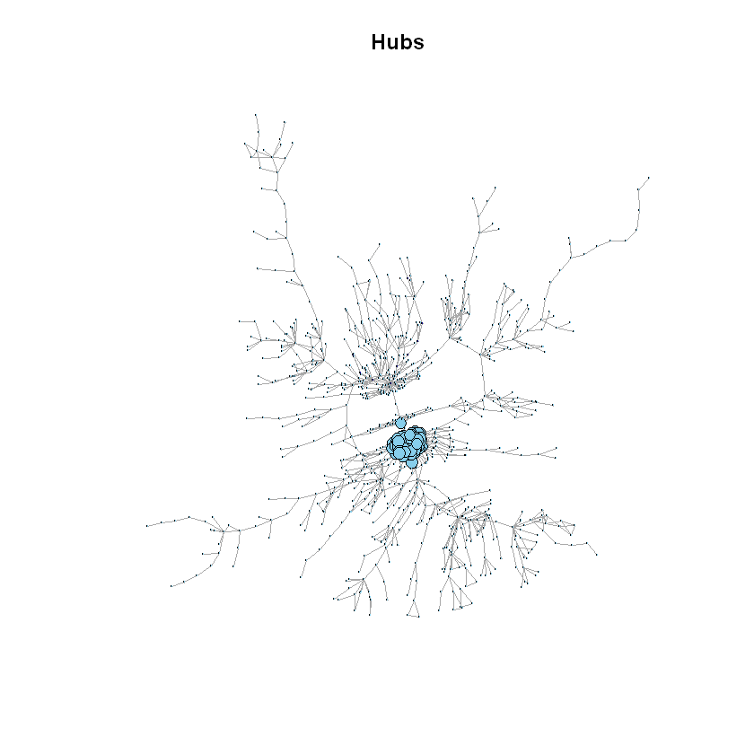

```r
# Hubs refer to max outgoing links whereas Authorities refer to max incoming links.
# Hubs are pages that are not necessarily relevant to the query string, they are pages good at pointing at things that
# maybe relevant. Given a query to a search engine: Root is set of highly relevant web pages(e.g. pages that contain the
# query string), i.e., the potential authorities. Potential hubs, on the other hand , are all the pages that link to a
# page in root.
hub<-hub.score(newgraph)$vector
auth<-authority.score(newgraph)$vector
plot(newgraph,
     vertex.size=hub*5,
     main = 'Hubs',
     vertex.color.hub = "skyblue",
     vertex.label=NA,
     edge.arrow.size=0.00001,
     layout = layout.kamada.kawai)
```

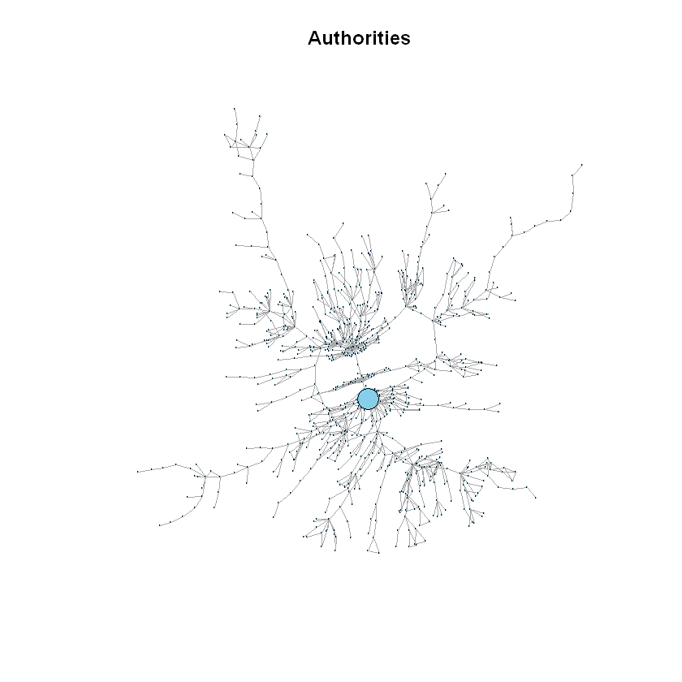

```r
plot(newgraph,
     vertex.size=auth*10,
     main = 'Authorities',
     vertex.color.auth = "skyblue",
     vertex.label=NA,
     edge.arrow.size=0.00001,
     layout = layout.kamada.kawai)
```

Creating a group of variables containing the information of neighbors that "point to" focal products. The variables include:

a. Neighbors' mean rating (nghb_mn_rating)

b. Neighbors' mean salesrank (nghb_mn_salesrank)

c. Neighbors' mean number of reviews (nghb_mn_review_cnt)

```r
sub_all1 <-as_ids(sub_all)
Book$id <- as.character(Book$id)
filtered <- Book[Book$id %in% sub_all1,]
copurchase$Target <- as.character(copurchase$Target)
```

```r
mean_values <- inner_join(copurchase, filtered, by = c("Target"="id")) %>%
  group_by(Target) %>%
  summarise(nghb_mn_rating = mean(rating),
            nghb_mn_salesrank = mean(salesrank),
            nghb_mn_review_cnt = mean(review_cnt))
```

```r
in_degree1 <- as.data.frame(deg2)
in_degree1 <- cbind(id = rownames(in_degree1), in_degree1)
out_degree1 <- as.data.frame(deg3)
out_degree1 <- cbind(id = rownames(out_degree1), out_degree1)

closeness1 <- as.data.frame(closeness)
closeness1 <- cbind(id = rownames(closeness1), closeness1)
betweenness1 <- as.data.frame(betweenness)
betweenness1 <- cbind(id = rownames(betweenness1), betweenness1)

hub_score2 <- as.data.frame(hub)
hub_score2 <- cbind(id = rownames(hub_score2), hub_score2)
authority_score2 <- as.data.frame(auth)
authority_score2 <- cbind(id = rownames(authority_score2), authority_score2)
```

### Poisson Regression

```r
# Fitting a Poisson regression to predict salesrank of all the books in this subcomponent using products' own information
# and their neighbor's information.
newdf1 <- sqldf("SELECT hub_score2.id,hub, betweenness, auth, closeness, deg2, deg3
                      FROM hub_score2, betweenness1, authority_score2, closeness1, in_degree1, out_degree1
                      WHERE hub_score2.id = betweenness1.id
                      and hub_score2.id = authority_score2.id
                      and hub_score2.id = closeness1.id
                      and hub_score2.id = in_degree1.id
                      and hub_score2.id = out_degree1.id")

newdf2 <- sqldf("SELECT Book.id, Book.review_cnt, Book.rating, hub, betweenness, auth, closeness,
                          deg2, deg3, Book.salesrank
                FROM Book, newdf1,mean_values
                WHERE newdf1.id = Book.id
                and Book.id=mean_values.Target")

summary(salesrank_prediction<- glm(salesrank ~ review_cnt + rating + hub + betweenness +
                                       auth + closeness + deg2 + deg3, family="poisson", data=newdf2))
```

```
Call:
glm(formula = salesrank ~ review_cnt + rating + hub + betweenness +
    auth + closeness + deg2 + deg3, family = "poisson", data = newdf2)

Deviance Residuals:
    Min       1Q   Median       3Q      Max
-367.17  -157.71   -10.47   127.91   486.93

Coefficients:
              Estimate Std. Error  z value Pr(>|z|)
(Intercept)  1.128e+01  7.131e-04 15825.51   <2e-16 ***
review_cnt  -3.640e-03  3.496e-06 -1041.14   <2e-16 ***
rating      -2.219e-02  8.289e-05  -267.68   <2e-16 ***
hub          1.351e-01  5.723e-04   236.12   <2e-16 ***
betweenness -5.204e-04  1.087e-05   -47.87   <2e-16 ***
auth         3.986e-01  4.650e-03    85.72   <2e-16 ***
closeness   -6.295e+01  5.744e+00   -10.96   <2e-16 ***
deg2        -1.644e-03  6.376e-05   -25.79   <2e-16 ***
deg3         4.976e-02  1.792e-04   277.71   <2e-16 ***
---
Signif. codes:  0 '***' 0.001 '**' 0.01 '*' 0.05 '.' 0.1 ' ' 1

(Dispersion parameter for poisson family taken to be 1)

    Null deviance: 28309713  on 903  degrees of freedom
Residual deviance: 26141889  on 895  degrees of freedom
AIC: 26153385

Number of Fisher Scoring iterations: 5
```

### Conclusion

From the regression result, we can see that all coefficients are highly significant with the small p-value. The coefficient for review_cnt is -3.640e-03. This means that the expected log count of sales rank for a one-unit increase in review_cnt is -3.640e-03. Since lower sales rank means higher sales, an increase in reviews decreases sales rank and increases sales. The coefficient for the rating is -2.219e-02 which indicates that the expected log count for a one-unit increase in rating is -2.219e-02. Since lower sales rank means higher sales, an increase in rating decreases sales rank and increases sales. The coefficient for the hub is 1.351e-01 which indicates that the expected log count for a one-unit increase in the hub is 1.351e-01. Since lower sales rank means higher sales, increase in hub score increases sales rank and decreases sales. The coefficient for betweenness is -5.204e-04, i.e., the expected log count for a one-unit increase in betweenness is -5.204e-04. Since lower sales rank means higher sales, increase in betweenness decreases sales rank, and increases sales. The coefficient for auth is 3.986e-01; the expected log count for a one-unit increase in auth is 3.986e-01. Since lower sales rank means higher sales, an increase in authority score increases sales rank and decreases sales. The coefficient for closeness is -6.295e+01, i.e the expected log count for a one-unit increase in closeness is -6.295e+01. Since lower sales rank means higher sales, increase in closeness decreases sales rank, and increases sales. The coefficient for deg2 is -1.644e-03, i.e. the expected log count for a one-unit increase in deg2 is -1.644e-03. Since lower sales rank means higher sales, increase in in-degree decreases sales rank, and increases sales. The coefficient for deg3 is 4.976e-02, i.e., the expected log count for a one-unit increase in deg3 is 4.976e-02. Since lower sales rank means higher sales, increase in out-degree increases sales rank, and decreases sales.